# The Great Green Wall, a large-scale institutional innovation in agri-food systems to combat food insecurity

Ramoudane Orou Sannou

2022-12-13

# Background

While 828 million people worldwide continue to go to bed hungry, an estimated 10 million hectares of forest are cleared yearly (about 27400 hectares per day). Yet, the conversion of forests into agricultural land does not seem to imply a systematic reduction of hunger worldwide, especially in developing countries. Alternatively, one can dare to hope for innovations aimed at reconverting degraded land into arable land or, better still, into forests, a better approach to fighting food insecurity.

As part of my doctoral research, I am seeking to better understand which farming systems lead to social sustainability. Social sustainability is concerned with several aspects of human and societal development, among which human well-being very often comes first. Food security is a major component of human well-being (Hammond et al., 2021) often included in agrifood systems’ social sustainability assessments as indicated in my previous paper (Orou Sannou & al, forthcoming ). This study aims to improve our understanding of the causal mechanisms leading to food security, considered as a social sustainability aspect. It estimates the effect of land use and land cover changes (we use this generic term to refer to changes in tree and crop cover) on food security in sub-Saharan African countries with a focus on countries participating in the Great Green Wall (GGW) initiative.

This Rmarkdown file contains the code I developed for the study and will not include extensive interpretations of the results. The draft manuscript is still undergoing some revisions before submission to a peer-reviewed journal.

# Data

- Since 2014 FAO conducts the Food Insecurity Experience Scale (FIES) survey in several countries across the world. This standardized survey helps to produce cross-country comparable food insecurity prevalence. Nationally representative **food insecurity** prevalence will be used as the dependent variable in this study.
- A mere combination of **trees and crops** is considered as a type of multifunctional land use. As such, using Dynamic World data (Brown et al., 2022), the percentage of tree and crop cover in the total area of selected countries will be used in an attempt to capture the effect of multifunctional land use on food security in this study.
- However, in order to improve the internal validity of the estimated parameters and to limit the effect of external confounding factors, we will control for other key aspects that could affect an individual’s food security such as **education level, health status, living conditions and climatic factors such as agricultural drought and political factors such as governance effectiveness**.
- UNDP defines the **Human Development Index (HDI)** as a summary measure of achievement in key dimensions of human development including the distribution of education, health and living standards. It will serve as a control variable in this study.
- Agricultural Drought Indicator: the six-month **Standardized Precipitation Index (SPI-6)** was used by Dasgupta and Robinson (2022) as a measure of agricultural drought. Our model considered a specification with annual mean SPI-06 and another with the **Risk of Drought Impact for Agriculture Index (RDrI-Agri)** which is a more robust indicator for agricultural drought that combines drought hazard, drought exposure and drought vulnerability aspects. The raster datasets were obtained from the Global Drought Observatory.
- Governance Effectiveness: **Government effectiveness** is a World Bank indicator that captures perceptions of the quality of many aspects of public services in a country such as the quality of the civil service and the degree of its independence from political pressures, the quality of policy formulation and implementation, and the credibility of the government’s commitment to such policies.

```r
library(haven)      # Import .dta or .sav datafiles
library(RM.weights) # Food insecurity prevalence using the rasch model
library(tidyverse)  # R ecosystem for different data manipulations and analyses
library(car)        # Companion to Applied Regression
library(gplots)     # For ploting
library(stargazer)  # Format laTeX tables
library(plm)        # linear model for panel data
library(tvReg)      # Time-varying regression
library(terra)      # For geo-data manipulation
library(ncdf4)      # Read and write NetCDF files
library(zoo)        # the zoo package for time series
library(rgdal)      # Geospatial projection/transformation operations
library(texreg)     # Conversion of R Regression Output to LaTeX or HTML Tables
```

# Load FIES datasets for Ethiopia, Mauritania, Niger and Senegal

In the following code chunk, I will load FIES dataset downloaded from [FAO Microdata Catalogue](https://microdata.fao.org/index.php). Only one code chunk (for Ethiopia) would be visible in the html version of this Rmarkdown.

```r
# the following code imports all datasets at once but in a list

eth.list <- list.files("Ethiopia", pattern="*.dta",
                       full.names = TRUE)

ethiopia <- lapply(eth.list, read_dta)

names(ethiopia) <- c("fies_eth_2014", "fies_eth_2015",
                     "fies_eth_2016", "fies_eth_2017",
                     "fies_eth_2018", "fies_eth_2019",
                     "fies_eth_2020")


ethiopia[["fies_eth_2015"]]
```

| Random_ID | WORRIED | HEALTHY | FEWFOOD | SKIPPED | ATELESS | RUNOUT | HUNGRY | WHLDAY | wt | year | N_adults | N_child | Raw_score | Raw_score_par | Raw_score_par_error | Prob_Mod_Sev | Prob_sev | Age | Education | Area | Gender | Income |
| --- | --- | --- | --- | --- | --- | --- | --- | --- | --- | --- | --- | --- | --- | --- | --- | --- | --- | --- | --- | --- | --- | --- |
| 122636047 | 1 | 1 | 1 | 1 | 1 | 0 | 0 | 0 | 0.4285058 | 1 | 02 | 05 | 5 | 0.50638132 | 0.4935010 | 0.95133239 | 2.765442e-03 | 29 | 1 | 2 | 1 | 2 |
| 201939853 | 1 | 1 | 1 | 1 | 1 | 1 | 1 | 0 | 1.3957166 | 1 | 04 | 06 | 7 | 1.65817682 | 0.6577725 | 0.99862742 | 3.705314e-01 | 38 | 1 | 2 | 2 | 2 |
| 167548251 | 1 | 1 | 1 | 1 | 1 | 0 | 0 | 0 | 1.2446776 | 1 | 04 | 02 | 5 | 0.50638132 | 0.4935010 | 0.95133239 | 2.765442e-03 | 21 | 2 | 2 | 1 | 1 |
| 111592287 | 1 | 1 | 1 | 0 | 0 | 0 | 0 | 0 | 1.7366999 | 1 | 03 | 02 | 3 | -0.34677354 | 0.4736770 | 0.47057109 | 1.355301e-06 | 50 | 1 | 2 | 1 | 1 |
| 174631949 | 1 | 1 | 1 | 1 | 1 | 0 | 0 | 0 | 0.6433439 | 1 | 03 | 03 | 5 | 0.50638132 | 0.4935010 | 0.95133239 | 2.765442e-03 | 19 | 2 | 2 | 2 | 1 |
| 195979180 | 1 | 1 | 1 | 0 | 0 | 0 | 0 | 0 | 0.8495213 | 1 | 02 | 06 | 3 | -0.34677354 | 0.4736770 | 0.47057109 | 1.355301e-06 | 30 | 1 | 2 | 2 | 1 |
| 157992839 | 1 | 1 | 1 | 0 | 0 | 1 | 0 | 0 | 1.7902736 | 1 | 02 | 04 | 4 | 0.07388289 | 0.4732149 | 0.79247147 | 7.025745e-05 | 24 | 1 | 2 | 1 | 1 |
| 192467578 | 1 | 1 | 1 | 0 | 0 | 1 | 0 | 0 | 2.0252201 | 1 | 04 | 04 | 4 | 0.07388289 | 0.4732149 | 0.79247147 | 7.025745e-05 | 40 | 1 | 2 | 1 | 2 |
| 117879777 | 0 | 0 | 0 | 0 | 0 | 0 | 0 | 0 | 1.0055754 | 1 | 02 | 00 | 0 | -1.83179543 | 0.8169690 | 0.00000000 | 0.000000e+00 | 22 | 1 | 1 | 2 | 5 |
| 195764962 | 0 | 0 | 0 | 0 | 0 | 0 | 0 | 0 | 1.0144417 | 1 | 05 | 00 | 0 | -1.83179543 | 0.8169690 | 0.00000000 | 0.000000e+00 | 23 | 2 | 1 | 1 | 5 |

[output cut: 990 more lines]

```r
#names(ethiopia)
```

This what the raw data of the FIES survey look like.

# Writting a Function for globally equated prevalence calculation

I have written a function called **fies.prev** that computes food insecurity prevalence at country level and uses the global standard to equate the obtained rates following the Rasch Model approach as described in detail by FAO. For more information visit this [website](https://www.fao.org/in-action/voices-of-the-hungry/fies/fr/). The function is saved as **Fies Prevalence** in the R project folder and can be accessed using *source(“Fies Prevalence”)*.

```r
 fies.prev <- function(data, year, country) {



  # The 2021 FIES dataset structure seems to differ from previous waves. Therefore, I start with
  # an if statement to handle the selection of corresponding columns

  if (colnames(data[ ,1]) == "Random_ID"){
     XX.data  <-  data[,2:9]
  } else {
    XX.data  <-  data[,1:8]
  }

  # Making sure all variables are coded as numeric
  XX.data  <-  data.frame(lapply(XX.data, as.numeric))

  # Saving FIES corresponding weights
  wt.data  <-  data$wt

  # Calculating raw scores (number of yes for each individual to the 8 questions)
  rv.data <- rowSums(XX.data)

  # Number of items (questions) of the FIES
  k <- ncol(XX.data)

  # Rash Model
  rr.data <- RM.w(XX.data, wt.data)

  # Pre-defined thresholds on the latent trait
  # sthresh contains two possible thresholds on the latent trait
  #sthresh <- c(-0.25, 1.81)

  #pp.data <- prob.assign(rr.data, sthres = sthresh)$sprob


  # VoH 2014-2015 global standard
  #b.tot <- c(-1.2590036, -0.8991436, -1.0876362,  0.4163556, -0.2506451,  0.4466926,  0.8065710, 1.8268093)

  # Equating of country 1 to the global standard
  ee <- equating.fun(rr.data, tol=0.5)

  # Equated prevalence rates
  prev <- ee$prevs*100

  # Correlation between common items
  cor <- ee$cor.comm.items


  # Dataframe of the prevalence rates and correlation
  results <- as.data.frame(cbind(prev, cor))

  # convert rownames into a new column nammed "measure"
  results$measure <- row.names(results)

  # remove the rownames
  rownames(results) <- NULL

  # create a "year" variable that will use the year argument provided in the function
  results$year <-  year

  # create a "country" variable that will use the country argument provided in the function
  results$country <- country

  # round results to two decimals
  results$prev <- round(results$prev, 2)

  results$cor <- round(results$cor, 2)
  #reorder the columns
  results <- dplyr::select(results, "country", "measure", "year", "prev", "cor")

  return(results)

}
```

# Food Insecurity Prevalences in selected countries

In this section I apply the *fies.prev* function to all survey waves conducted in Africa Great Green Wall Countries having more than 3 waves of the survey (Ethiopia, Mauritania, Niger, Senegal).

## Ethiopia

| country | measure | year | prev | cor |
| --- | --- | --- | --- | --- |
| Ethiopia | FI_mod+ | 2014 | 51.36 | 0.98 |
| Ethiopia | FI_sev | 2014 | 11.23 | 0.98 |
| Ethiopia | FI_mod+ | 2015 | 51.59 | 0.98 |
| Ethiopia | FI_sev | 2015 | 9.69 | 0.98 |
| Ethiopia | FI_mod+ | 2016 | 61.31 | 0.98 |
| Ethiopia | FI_sev | 2016 | 11.61 | 0.98 |
| Ethiopia | FI_mod+ | 2017 | 56.04 | 0.96 |
| Ethiopia | FI_sev | 2017 | 9.41 | 0.96 |
| Ethiopia | FI_mod+ | 2018 | 52.89 | 0.98 |
| Ethiopia | FI_sev | 2018 | 10.47 | 0.98 |

[output cut: 4 more lines]

## Mauritania

| country | measure | year | prev | cor |
| --- | --- | --- | --- | --- |
| Mauritania | FI_mod+ | 2014 | 21.00 | 0.97 |
| Mauritania | FI_sev | 2014 | 6.79 | 0.97 |
| Mauritania | FI_mod+ | 2015 | 30.75 | 0.99 |
| Mauritania | FI_sev | 2015 | 10.70 | 0.99 |
| Mauritania | FI_mod+ | 2016 | 43.45 | 0.98 |
| Mauritania | FI_sev | 2016 | 17.89 | 0.98 |
| Mauritania | FI_mod+ | 2017 | 47.71 | 0.96 |
| Mauritania | FI_sev | 2017 | 17.95 | 0.96 |
| Mauritania | FI_mod+ | 2018 | 42.06 | 0.99 |
| Mauritania | FI_sev | 2018 | 20.93 | 0.99 |

[output cut: 2 more lines]

## Niger

| country | measure | year | prev | cor |
| --- | --- | --- | --- | --- |
| Niger | FI_mod+ | 2014 | 61.33 | 0.96 |
| Niger | FI_sev | 2014 | 16.19 | 0.96 |
| Niger | FI_mod+ | 2015 | 57.52 | 0.99 |
| Niger | FI_sev | 2015 | 22.24 | 0.99 |
| Niger | FI_mod+ | 2016 | 75.71 | 0.99 |
| Niger | FI_sev | 2016 | 42.38 | 0.99 |
| Niger | FI_mod+ | 2017 | 83.67 | 0.97 |
| Niger | FI_sev | 2017 | 53.99 | 0.97 |
| Niger | FI_mod+ | 2018 | 80.58 | 0.97 |
| Niger | FI_sev | 2018 | 63.36 | 0.97 |

[output cut: 2 more lines]

## Senegal

| country | measure | year | prev | cor |
| --- | --- | --- | --- | --- |
| Senegal | FI_mod+ | 2014 | 23.66 | 0.99 |
| Senegal | FI_sev | 2014 | 5.27 | 0.99 |
| Senegal | FI_mod+ | 2015 | 38.31 | 0.97 |
| Senegal | FI_sev | 2015 | 10.49 | 0.97 |
| Senegal | FI_mod+ | 2016 | 47.59 | 0.97 |
| Senegal | FI_sev | 2016 | 11.89 | 0.97 |
| Senegal | FI_mod+ | 2017 | 39.68 | 0.97 |
| Senegal | FI_sev | 2017 | 18.40 | 0.97 |
| Senegal | FI_mod+ | 2018 | 37.48 | 0.95 |
| Senegal | FI_sev | 2018 | 14.23 | 0.95 |

[output cut: 2 more lines]

## Subsaharan countries not part of the GGW initiative

For efficiency, I am writing a for loop to compute FI prevalence for all countries.

```r
naggw.list <- list.files("naggw_fies", pattern="*.dta",
                       full.names = TRUE)



naggw.df <- data.frame(matrix(ncol = 5, nrow = 0))



for (i in 1:length(naggw.list)) {

  #extracting country's short name
  country <- substr(basename(naggw.list[i]),1,
                 nchar(basename(naggw.list[i]))-33)

  #extracting year of data
  year <- substr(basename(naggw.list[i]),5,
                 nchar(basename(naggw.list[i]))-28)

  # assign each survey file from the list to an object called dta.file
  dta.file <- naggw.list[i]

  # reading the raw fies survey data
  fies.data <- haven::read_dta(dta.file)

  # country prevalence calculation
  country_prev <- fies.prev(fies.data, year, country)

  # saving all countries prevalence in one dataframe
  naggw.df <- rbind(naggw.df, country_prev)



}

#naggw.df
```

```r
naggw.df <- naggw.df %>%
  mutate(country =   ifelse(country == "BWA", "Botswana",
                     ifelse(country == "CMR", "Cameroon",
                     ifelse(country == "GIN", "Guinea",
                     ifelse(country == "LBR", "Liberia",
                     ifelse(country == "MOZ", "Mozambique",
                     ifelse(country == "SLE", "Sierra Leone",
                     ifelse(country == "TGO", "Togo",
                     ifelse(country == "ZAF", "South Africa",
                     ifelse(country == "ZWE", "Zimbabwe", " "))))))))))

naggw.df
```

| country | measure | year | prev | cor |
| --- | --- | --- | --- | --- |
| Botswana | FI_mod+ | 2014 | 53.14 | 0.98 |
| Botswana | FI_sev | 2014 | 30.73 | 0.98 |
| Botswana | FI_mod+ | 2015 | 60.14 | 0.97 |
| Botswana | FI_sev | 2015 | 28.88 | 0.97 |
| Botswana | FI_mod+ | 2016 | 64.01 | 0.96 |
| Botswana | FI_sev | 2016 | 32.51 | 0.96 |
| Botswana | FI_mod+ | 2017 | 72.20 | 0.95 |
| Botswana | FI_sev | 2017 | 46.82 | 0.95 |
| Botswana | FI_mod+ | 2018 | 66.09 | 0.95 |
| Botswana | FI_sev | 2018 | 35.21 | 0.95 |

[output cut: 92 more lines]

# Food Insecusity by Gender

I have written another function saved as “Fies Prevalence Gender.R” to compute FI by gender. I will import it here and use it in a for loop. Like in the previous section, a for loop here will help move fast.

```r
 source("Fies Prevalence Gender.R")

all.list <- list.files("All", pattern="*.dta",
                       full.names = TRUE)



all.df <- data.frame(matrix(ncol = 3, nrow = 0))



for (i in 1:length(all.list)) {

  #extracting country's short name
  country <- substr(basename(all.list[i]),1,
                 nchar(basename(all.list[i]))-33)

  #extracting year of data
  year <- substr(basename(all.list[i]),5,
                 nchar(basename(all.list[i]))-28)

  dta.file <- all.list[i]

  fies.data <- haven::read_dta(dta.file)

  country_prev <- fies.prev.gender(fies.data, year, country)

  all.df <- rbind(all.df, country_prev)



}


#View(all.df)
```

```r
# filter all years not equal to 2014
all.df <- all.df %>% filter(year != "2014")
#all.df

all_wide <- pivot_wider(all.df,
                         names_from = "measure",
                         values_from = "prev") %>%
#select important variables
 select("country", "year", "gender", "FI_mod+", "FI_sev") %>%
#rename "FI_mod+" to "FI_mod"
 rename(FI_mod = "FI_mod+")

all_wide
```

| country | year | gender | FI_mod | FI_sev |
| --- | --- | --- | --- | --- |
| BWA | 2015 | male | 57.73027 | 26.179396 |
| BWA | 2015 | female | 62.52762 | 31.365452 |
| BWA | 2016 | male | 66.52374 | 34.249217 |
| BWA | 2016 | female | 63.18734 | 31.294245 |
| BWA | 2017 | male | 66.97425 | 44.899839 |
| BWA | 2017 | female | 72.83798 | 42.125027 |
| BWA | 2018 | male | 57.55202 | 25.402451 |
| BWA | 2018 | female | 69.82428 | 39.015422 |
| BWA | 2019 | male | 62.37555 | 30.926902 |
| BWA | 2019 | female | 67.66701 | 38.713655 |

[output cut: 118 more lines]

```r
# For moderate FI
all_wide %>%
  group_by(country, gender) %>%
  summarise(mean = mean(FI_mod))
```

| country | gender | mean |
| --- | --- | --- |
| BWA | female | 67.20885 |
| BWA | male | 62.23117 |
| CMR | female | 66.92580 |
| CMR | male | 65.91067 |
| ETH | female | 52.71499 |
| ETH | male | 56.22305 |
| GIN | female | 70.85859 |
| GIN | male | 71.62363 |
| LBR | female | 84.82835 |
| LBR | male | 84.25423 |

[output cut: 16 more lines]

```r
# For severe FI
all_wide %>%
  group_by(country, gender) %>%
  summarise(mean = mean(FI_sev))
```

| country | gender | mean |
| --- | --- | --- |
| BWA | female | 36.50276 |
| BWA | male | 32.33156 |
| CMR | female | 33.04681 |
| CMR | male | 35.37233 |
| ETH | female | 11.68261 |
| ETH | male | 12.02006 |
| GIN | female | 43.90623 |
| GIN | male | 43.12513 |
| LBR | female | 48.90083 |
| LBR | male | 42.26753 |

[output cut: 16 more lines]

# Visualize food insecurity prevalence by gender

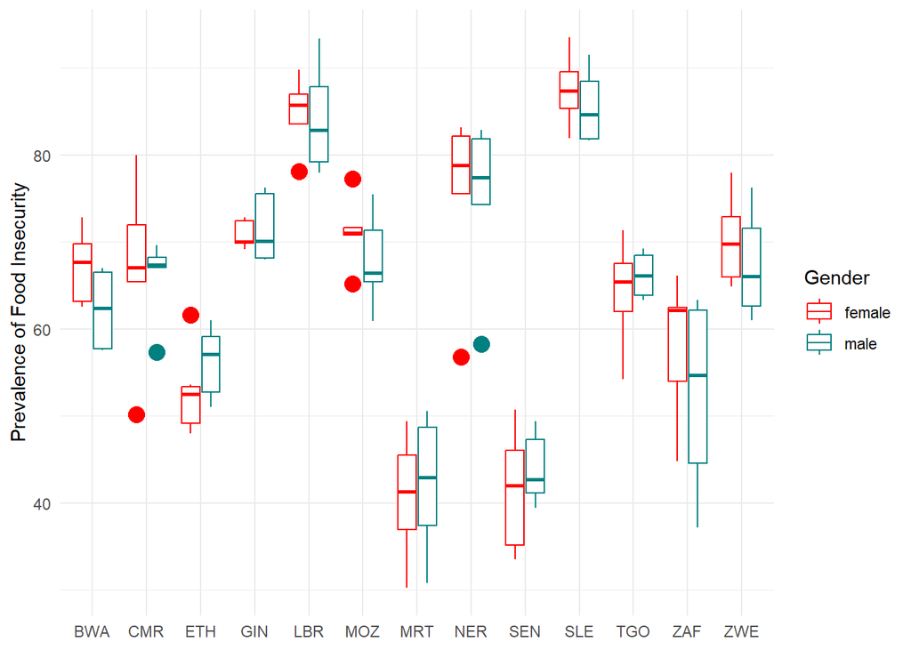

# Visualize food insecurity prevalence in GGW countries

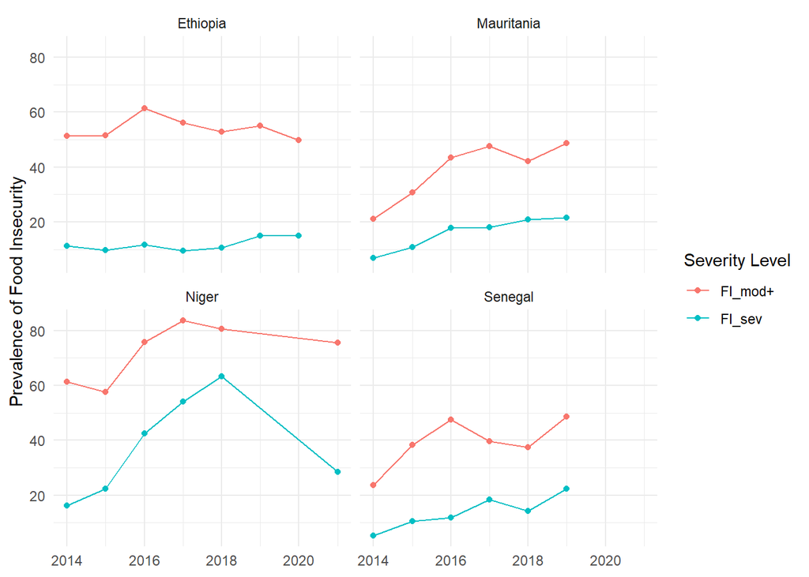

```r
plot_aggw <- ggplot(aggw.df ,
                    aes(x= as.integer(year), y=prev, group = measure,
                         col = measure))+
  geom_point() +
  geom_line()+
  facet_wrap(~country) +
  labs(x = NULL, y = "Prevalence of Food Insecurity", col = "Severity Level") +
  theme_minimal()

plot_aggw
```

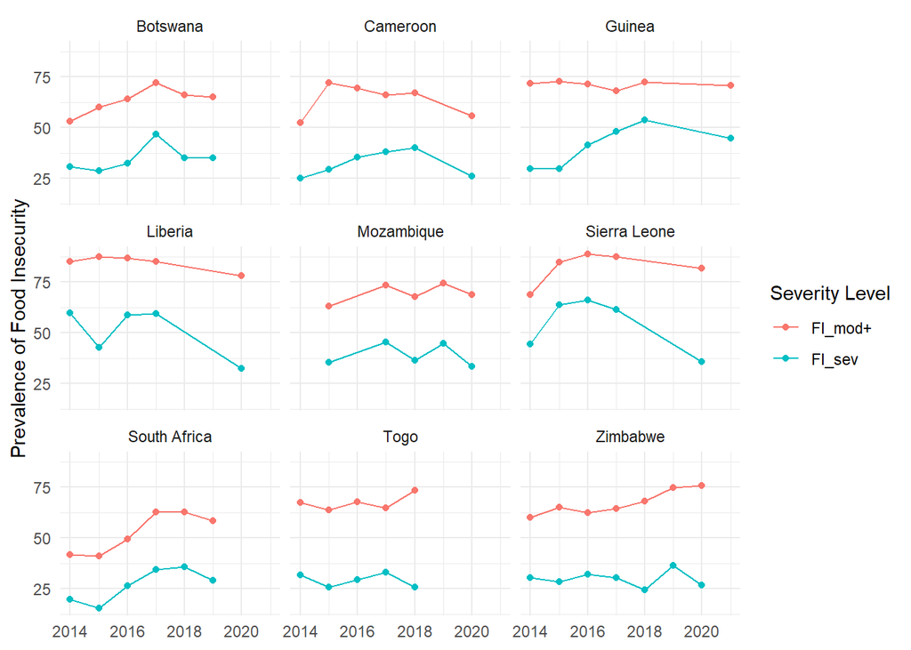

```r
plot_naggw <- ggplot(naggw.df ,
                    aes(x= as.integer(year), y=prev, group = measure,
                         col = measure))+
  geom_point() +
  geom_line()+
  facet_wrap(~country) +
  labs(x = NULL, y = "Prevalence of Food Insecurity", col = "Severity Level") +
  theme_minimal()

plot_naggw
```

### Boxplot

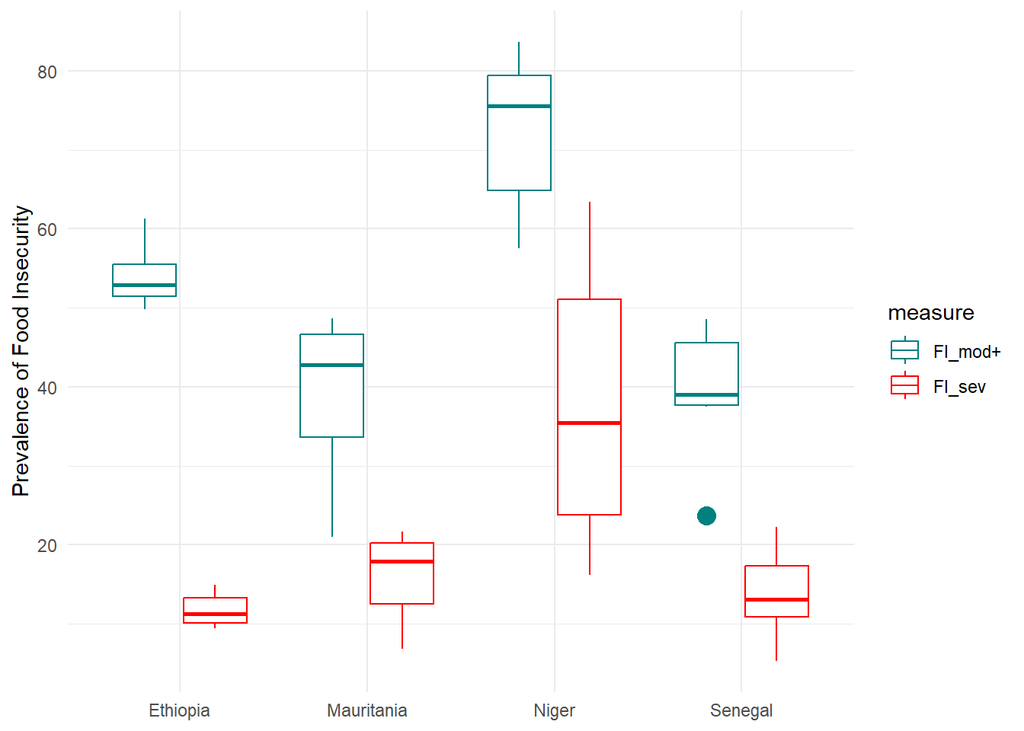

```r
bxplt_aggw <- ggplot(aggw.df ,
                    aes(x= country, y=prev, col = measure))+
  geom_boxplot(outlier.size=4) +
  #facet_wrap(~measure) +
  labs(x = NULL, y = "Prevalence of Food Insecurity") +
  theme_minimal()+
  scale_color_manual(values=c("#008080", "#FF0000"))

bxplt_aggw
```

# Visualize food insecurity prevalence in not GGW initiative countries

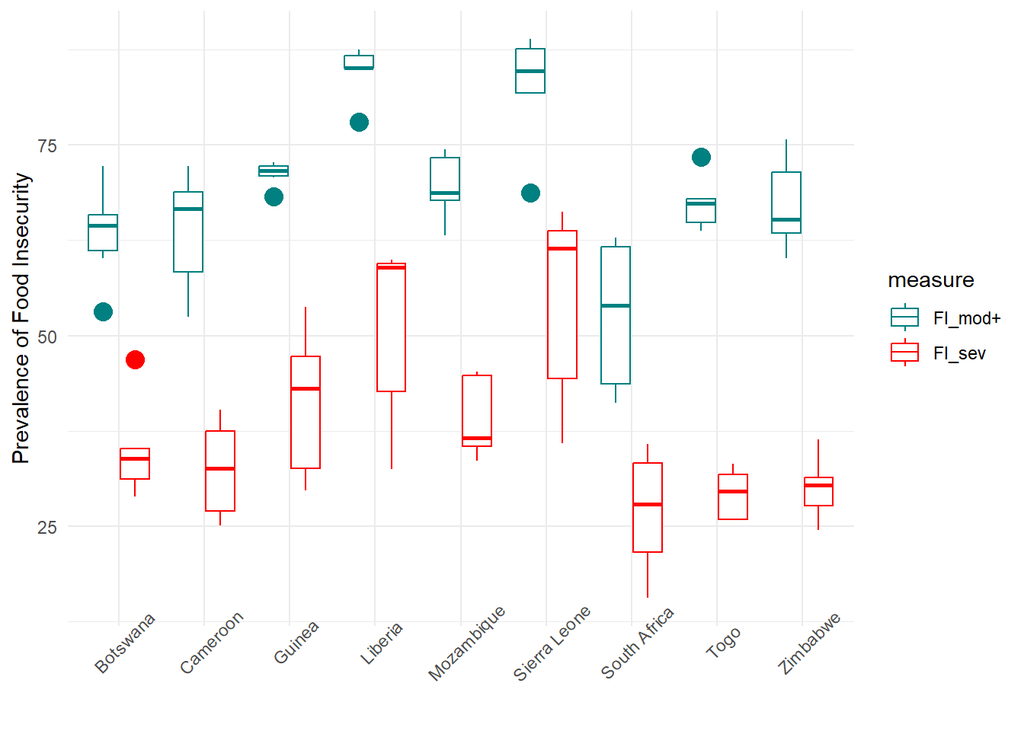

```r
bxplt_naggw <- ggplot(naggw.df ,
                    aes(x= country, y=prev, col = measure))+
  geom_boxplot(outlier.size=4) +
  #facet_wrap(~measure) +
  labs(x = NULL, y = "Prevalence of Food Insecurity") +
  theme_minimal()+
  theme(axis.text.x =
            element_text(angle = 45)) +
  scale_color_manual(values=c("#008080", "#FF0000"))

bxplt_naggw
```

# Dynamic World : A near realtime land cover dataset

[Dynamic World](https://dynamicworld.app/) time series were retrieved on Google Earth Engine using the python package geemap.  
Based on dynamic world time series, the area for each land cover class was computed for each country. I considered the country borders provided by [FAO’s 2015 Global Administrative Unit Layers](https://developers.google.com/earth-engine/datasets/catalog/FAO_GAUL_2015_level0). The python code used for area calculations is saved as “Land_cover_areas_calculations” and can be found in the project folder. For each country, we consider the [crop calendars provided by USDA](https://ipad.fas.usda.gov/ogamaps/cropcalendar.aspx) to select the most appropriate months to extract land cover classification time series. This helps to lower the risk of calculating land classes that will be biased for the “crops” class.

```r
#import LULC data derived from Dynamic World Land Cover data on GEE

lulc <- read_csv("LULC_data.csv")

#head(lulc)

# remove the land cover type "snow_and_ice" as it is meaningless in the studied areas
lulc <- lulc %>% filter(group != "snow_and_ice")

lulc %>%
  filter(group %in%  c("trees", "crops")) %>%
  group_by(country, group) %>%
  summarise(mean = 100*mean(percentage))
```

| country | group | mean |
| --- | --- | --- |
| Ethiopia | crops | 16.44285714 |
| Ethiopia | trees | 24.06000000 |
| Mauritania | crops | 2.13000000 |
| Mauritania | trees | 0.05714286 |
| Niger | crops | 1.86285714 |
| Niger | trees | 0.22428571 |
| Senegal | crops | 9.62000000 |
| Senegal | trees | 30.77571429 |

## LULC trends

### For GGW initiative countries

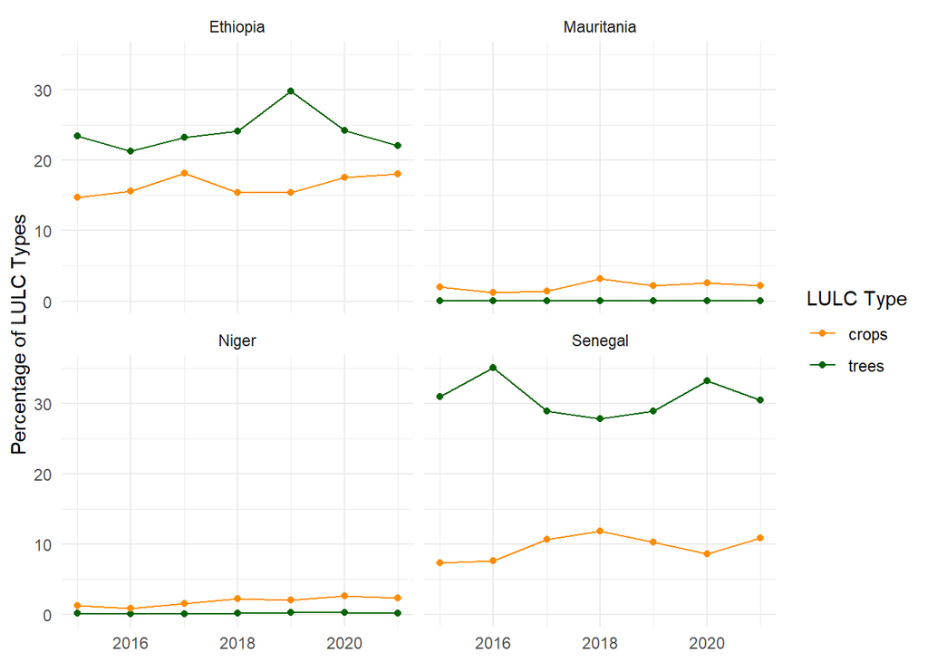

### For not GGW initiative countries

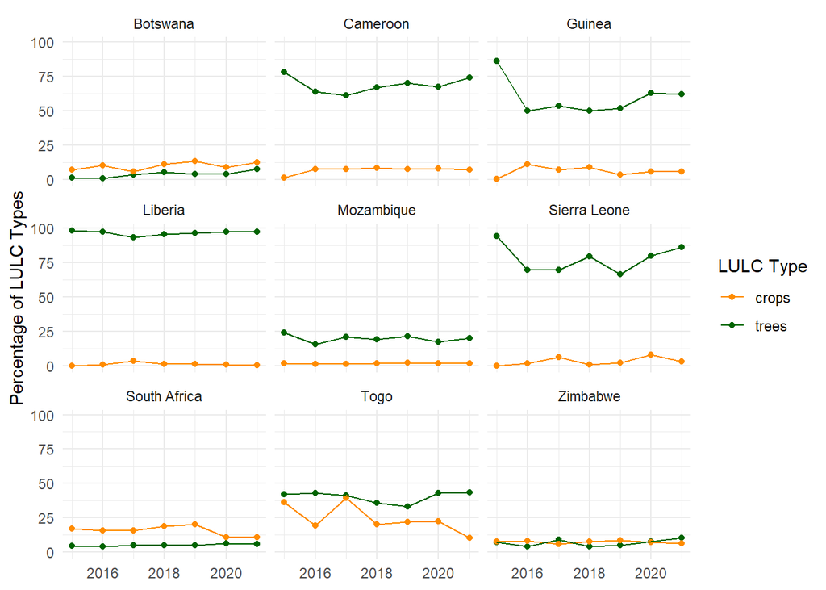

```r
#import LULC data derived from Dynamic World Land Cover data on GEE

naggw_lulc <- read_csv("Non_Sahelian.csv")

plot_naggw_lulc <- ggplot(naggw_lulc %>%
                      filter(group %in%  c("trees", "crops")),
                    aes(x= as.integer(year), y=100*percentage,
                        group = group,
                         col = group))+
  geom_point() +
  geom_line()+
  facet_wrap(~country) +
  labs(x = NULL, y = "Percentage of LULC Types", col = "LULC Type") +
  theme_minimal() +
  scale_colour_manual(values = c("darkorange", "darkgreen"))

plot_naggw_lulc
```

# The Subnational Human Development Index

[The sub-national Human Development Index (SHDI) database](https://hdr.undp.org/content/subnational-human-development-index-moving-beyond-country-level-averages) contains data from 163 countries, aggregating education, health, and standard of living dimensions. I extracted data for the four countries of interest as well as the years of interest and will import it in the following code chunk.

```r
# import hdi for aggw initiative countries
hdi <- read_csv("GDL-Sub-national-HDI-data.csv")

names(hdi) <- tolower(names(hdi))

#head(hdi)

# import hdi for not aggw initiative countries


naggw_hdi <- read_csv("NSahel-HDI-data.csv")

names(naggw_hdi) <- tolower(names(naggw_hdi))

# prepared another dataset containing all countries and the three sub-components of the hdi

hdi_all <- read_csv("hdi_all.csv")

names(hdi_all) <- tolower(names(hdi_all))

#View(hdi_all)
```

# The World Bank Governance Index

```r
library(readxl)
wgi <- read_excel(path = "wgidataset.xlsx",
                  sheet =  "GovernmentEffectiveness")

#View(wgi)
```

# [The Fragile States Index](https://fragilestatesindex.org/methodology/)

```r
fsi <- read_excel(path = "Fragility.xlsx")

names(fsi) <- tolower(names(fsi))
fsi <- fsi %>% select(country, year, total)

fsi <- rename(fsi, "fsi"= "total")

fsi$fsi <- round(fsi$fsi, 2)

fsi$year <- as.integer(fsi$year)

fsi <- fsi %>% filter(year %in% 2015:2020)

#View(fsi)
```

# Agricultural Drought Indicators

## The Standardized Precipitation Index (SPI)

SPI is is a statistical index comparing the total precipitation received at a particular location during a period of n months with the long-term precipitation distribution for the same period of time at that location (reference period is 1981-2010). Monthly accumulation periods (n) are 1, 3, 6, 9, 12, 24 or 48 months. The corresponding SPIs are denoted as SPI-1, SPI-3, SPI-6, etc. We use the SPI-6 in this study.

```r
# import spi files from 2014 to 2020

spi_files <- list.files("SPI", pattern = ".nc$", full.names = TRUE)
#spi_files

# read and print spi dataset for 2020
print(rast(spi_files[7]))
```

```
## class       : SpatRaster
## dimensions  : 180, 360, 12  (nrow, ncol, nlyr)
## resolution  : 1, 1  (x, y)
## extent      : -180, 180, -90, 90  (xmin, xmax, ymin, ymax)
## coord. ref. : lon/lat WGS 84
## source      : spg06_m_wld_20200101_20201201_m.nc
## varname     : spg06
## names       :       spg06_1,       spg06_2,       spg06_3,       spg06_4,       spg06_5,       spg06_6, ...
## unit        : dimensionless, dimensionless, dimensionless, dimensionless, dimensionless, dimensionless, ...
## time (days) : 2020-01-01 to 2020-12-01
```

```r
spi_list <- lapply(spi_files, rast)

#print(spi_list[[4]])

# assign names to each file
names(spi_list) <- c("spi_2014", "spi_2015", "spi_2016",
               "spi_2017", "spi_2018", "spi_2019", "spi_2020")
```

## The Risk of Drought Impacts for Agriculture (RDrI-Agri)

The Risk of Drought Impact for Agriculture (RDrI-Agri) is a robust indicator that combines drought hazard, drought exposure and drought vulnerability aspects. The drought hazard component is calculated by integrating three main drought indicators: the Standardized Precipitation Index (SPI), the Soil Moisture Anomaly (SMA), the FAPAR Anomaly. The drought exposure component integrates four indicators including the population, agricultural lands, livestock and water stress. Drought vulnerability is calculated as the propensity of exposed elements to suffer adverse effects when impacted by a drought event. I will import raster files of RDrI-Agri and extract the mean RDrI-Agri of the study locations.

```r
# import RDrI files from 2014 to 2020

rdri_files <- list.files("RDrI", pattern = ".nc$", full.names = TRUE)
#spi_files

# read and print RDrI dataset for 2020
print(rast(rdri_files[7]))
```

```
## class       : SpatRaster
## dimensions  : 180, 360, 36  (nrow, ncol, nlyr)
## resolution  : 1, 1  (x, y)
## extent      : -180, 180, -90, 90  (xmin, xmax, ymin, ymax)
## coord. ref. : lon/lat WGS 84
## source      : rdria_m_wld_20200101_20201221_t.nc
## varname     : rdria
## names       :       rdria_1,       rdria_2,       rdria_3,       rdria_4,       rdria_5,       rdria_6, ...
## unit        : dimensionless, dimensionless, dimensionless, dimensionless, dimensionless, dimensionless, ...
## time (days) : 2020-01-01 to 2020-12-21
```

```r
rdri_list <- lapply(rdri_files, rast)

#print(rdri_list[[4]])

# assign names to each file
names(rdri_list) <- c("rdri_2014", "rdri_2015", "rdri_2016",
               "rdri_2017", "rdri_2018", "rdri_2019", "rdri_2020")
```

## Import and read shape files of selected study coutries

```r
aggw_shp_files <- list.files("Shp/aggw_shp", pattern = ".shp$", full.names = TRUE)


#shape_files <- unlist(shape_files)

aggw_shp <- lapply(aggw_shp_files, readOGR)
#aggw_shp[1]


# assign names to each file
names(aggw_shp) <- c("eth_shp", "mrt_shp", "ner_shp",
               "sen_shp")

afr_shp <- readOGR("Shp/afr_shp/afr_g2014_2013_0.shp")
```

```r
#plot(afr_shp)
```

```r
naggw_shp_files <- list.files("Shp/naggw_shp", pattern = ".shp$", full.names = TRUE)


#shape_files <- unlist(shape_files)

naggw_shp <- lapply(naggw_shp_files, readOGR)
#shape_files[1]


# assign names to each file
names(naggw_shp) <- c("bwa_shp", "cmr_shp", "gin_shp",
                      "lbr_shp", "moz_shp", "sle_shp",
                      "tgo_shp", "zaf_shp", "zwe_shp")
```

## Write “spi.extr” function to extract the SPI stats

```r
spi.extr <- function(shp.file, spi.file,  stat,
                      spi.country) {

  #ensure shpfile projection matches with spifile projection
  projected <- sp::spTransform(shp.file, CRS = crs(spi.file))

  # clip spifile to country borders
  spi_clip <- terra::crop(spi.file, projected, snap = "out")

  # create a raster stack from the clipped country spi
  stack <- raster::stack(spi_clip)

  # mask values
  masked <- terra::mask(stack, projected)

  # compute stats and format as dataframe with more
  # intuitive rowmanes
  stat <- data.frame(raster::cellStats(masked, stat = stat),
                     row.names = c("SPI06-Jan","SPI06-Feb",
                                   "SPI06-Mar", "SPI06-Apr",
                                   "SPI06-May", "SPI06-Jun",
                                   "SPI06-Jul", "SPI06-Aug",
                                   "SPI06-Sep", "SPI06-Oct",
                                   "SPI06-Nov", "SPI06-Dec"))

  # rownames to a new column
  stat$month <- row.names(stat)
  # drop rownames
  row.names(stat) <- NULL
  # rename values column
  names(stat)[1] ="value"
  # round value to 4 decimal points
  stat$value <- round(stat$value, 4)
  # assign year
  #stat$year <- spi.year
  #assign country name
  stat$country <- spi.country
  # reorder columns
  stat <- stat[, c(3, 2, 1)]
  #stat <- dplyr::select(stat, "country",  "month", "value")
  return(stat)

}
```

## Write “rdri.extr” function to extract the RDrI stats

```r
rdri.extr <- function(shp.file, rdri.file,  stat,
                      rdri.country) {

  #ensure shpfile projection matches with spifile projection
  projected <- sp::spTransform(shp.file, CRS = crs(rdri.file))

  # clip spifile to country borders
  rdri_clip <- terra::crop(rdri.file, projected, snap = "out")

  # create a raster stack from the clipped country spi
  stack <- raster::stack(rdri_clip)

  # mask values
  masked <- terra::mask(stack, projected)

  # compute stats and format as dataframe with more
  # intuitive rowmanes
  stat <- data.frame(raster::cellStats(masked, stat = stat),
                     row.names = c("rdria_1","rdria_2", "rdria_3", "rdria_4",
                                   "rdria_5","rdria_6", "rdria_7", "rdria_8",
                                   "rdria_9","rdria_10", "rdria_11", "rdria_12",
                                   "rdria_13","rdria_14", "rdria_15", "rdria_16",
                                   "rdria_17","rdria_18", "rdria_19", "rdria_20",
                                   "rdria_21","rdria_22", "rdria_23", "rdria_24",
                                   "rdria_25","rdria_26", "rdria_27", "rdria_28",
                                   "rdria_29","rdria_30", "rdria_31", "rdria_32",
                                   "rdria_33","rdria_34", "rdria_35", "rdria_36"))

  # rownames to a new column
  stat$period <- row.names(stat)
  # drop rownames
  row.names(stat) <- NULL
  # rename values column
  names(stat)[1] ="value"
  # round value to 4 decimal points
  stat$value <- round(stat$value, 2)
  # assign year
  #stat$year <- spi.year
  #assign country name
  stat$country <- rdri.country
  # reorder columns
  stat <- stat[, c(3, 2, 1)]
  #stat <- dplyr::select(stat, "country",  "month", "value")
  return(stat)

}
```

## Calculate SPI for all countries and all years

The following for loop iterates through the shape file of each country and extract the monthly SPI-06 value for each year.

```r
spi.year <- c("2014" ,"2015", "2016", "2017", "2018", "2019", "2020")

countries <- c("Ethiopia", "Mauritania", "Niger", "Senegal")




#df <- data.frame(country = 0, month = 0, value = 0, year = 0)

df <- data.frame(matrix(ncol = 4, nrow = 0))

for (i in 1:length(aggw_shp)) {


 shp.file <- aggw_shp[[i]]

# df <- data.frame(matrix(ncol = 3, nrow = 0))
 #df <- data.frame(country = 0, month= 0, value = 0, year = 0)


  for (j in 1:length(spi_list)){


    spi.file <- spi_list[[j]]

    shp.country <- countries[i]

     spi <- spi.extr(shp.file, spi.file,
                  stat= "mean",spi.country = shp.country)

     spi$year <- spi.year[j]

     df <- rbind(df, spi)
  }



}

#df

#write.csv(df, "spi.df")
```

## Mean, Minimum and Maximum SPI for each country by year

| country | year | spi.mean |
| --- | --- | --- |
| Ethiopia | 2015 | -0.27986667 |
| Ethiopia | 2016 | 0.13252500 |
| Ethiopia | 2017 | -0.15953333 |
| Ethiopia | 2018 | 0.31322500 |
| Ethiopia | 2019 | 0.25412500 |
| Ethiopia | 2020 | 0.63484167 |
| Mauritania | 2015 | 0.06685833 |
| Mauritania | 2016 | 0.25235000 |
| Mauritania | 2017 | -0.16694167 |
| Mauritania | 2018 | 0.25278333 |

[output cut: 14 more lines]

| country | year | spi.mean |
| --- | --- | --- |
| Botswana | 2015 | -0.397716667 |
| Botswana | 2016 | -0.439725000 |
| Botswana | 2017 | 0.472041667 |
| Botswana | 2018 | -0.115241667 |
| Botswana | 2019 | -0.574075000 |
| Botswana | 2020 | 0.668050000 |
| Cameroon | 2015 | -0.525516667 |
| Cameroon | 2016 | 0.476558333 |
| Cameroon | 2017 | -0.287833333 |
| Cameroon | 2018 | 0.063400000 |

[output cut: 44 more lines]

## Calculate RDrI for all countries and all years

Using a for loop for more efficiency. However, I will set *echo = FALSE* so the code chunk will not appear in the *.html* file.

| country | year | rdri.mean |
| --- | --- | --- |
| Ethiopia | 2015 | 1.51 |
| Ethiopia | 2016 | 1.41 |
| Ethiopia | 2017 | 1.52 |
| Ethiopia | 2018 | 1.04 |
| Ethiopia | 2019 | 0.52 |
| Ethiopia | 2020 | 0.02 |
| Mauritania | 2015 | 1.02 |
| Mauritania | 2016 | 1.03 |
| Mauritania | 2017 | 1.03 |
| Mauritania | 2018 | 1.16 |

[output cut: 14 more lines]

| country | year | rdri.mean |
| --- | --- | --- |
| Botswana | 2015 | 1.16 |
| Botswana | 2016 | 1.51 |
| Botswana | 2017 | 1.24 |
| Botswana | 2018 | 1.23 |
| Botswana | 2019 | 1.00 |
| Botswana | 2020 | 0.12 |
| Cameroon | 2015 | 1.58 |
| Cameroon | 2016 | 1.43 |
| Cameroon | 2017 | 1.25 |
| Cameroon | 2018 | 1.15 |

[output cut: 44 more lines]

# Data Prepartion

Note that the same data transformation is applied to non AGGW countries but will not appear in the .html file.

## Long to wide food insecurity dataset

```r
# filter all years not equal to 2014
aggw.df <- aggw.df %>% filter(year != "2014")
#aggw.df

aggw_wide <- pivot_wider(aggw.df,
                         names_from = "measure",
                         values_from = "prev") %>%
#select important variables
 select("country", "year", "FI_mod+", "FI_sev") %>%
#rename "FI_mod+" to "FI_mod"
 rename(FI_mod = "FI_mod+")

aggw_wide
```

| country | year | FI_mod | FI_sev |
| --- | --- | --- | --- |
| Ethiopia | 2015 | 51.59 | 9.69 |
| Ethiopia | 2016 | 61.31 | 11.61 |
| Ethiopia | 2017 | 56.04 | 9.41 |
| Ethiopia | 2018 | 52.89 | 10.47 |
| Ethiopia | 2019 | 54.99 | 14.87 |
| Ethiopia | 2020 | 49.77 | 14.96 |
| Mauritania | 2015 | 30.75 | 10.70 |
| Mauritania | 2016 | 43.45 | 17.89 |
| Mauritania | 2017 | 47.71 | 17.95 |
| Mauritania | 2018 | 42.06 | 20.93 |

[output cut: 11 more lines]

```r
# aggw_wide %>%
#   group_by(country) %>%
#   summarise(mean = mean(FI_mod))
#
# aggw_wide %>%
#   group_by(country) %>%
#   summarise(mean = mean(FI_sev))
```

| country | year | FI_mod | FI_sev |
| --- | --- | --- | --- |
| Botswana | 2015 | 60.14 | 28.88 |
| Botswana | 2016 | 64.01 | 32.51 |
| Botswana | 2017 | 72.20 | 46.82 |
| Botswana | 2018 | 66.09 | 35.21 |
| Botswana | 2019 | 64.93 | 35.14 |
| Cameroon | 2015 | 72.22 | 29.54 |
| Cameroon | 2016 | 69.36 | 35.52 |
| Cameroon | 2017 | 66.09 | 38.12 |
| Cameroon | 2018 | 67.11 | 40.23 |
| Cameroon | 2020 | 55.73 | 26.13 |

[output cut: 33 more lines]

## Long to wide dynamic world data

Dynamic world Lulc data starts from 2015 while all four countries have food security data starting from 2014. I will drop the food insecurity prevalences for 2014 before joining both datasets.

```r
lulc <- mutate(lulc, percentage = 100*percentage)

lulc_wide <- lulc %>%  select("country", "year", "group", "percentage") %>%
  pivot_wider(names_from = "group", values_from = "percentage")   %>%
  select("country", "year" ,"trees", "crops", "bare")
lulc_wide
```

| country | year | trees | crops | bare |
| --- | --- | --- | --- | --- |
| Ethiopia | 2015 | 23.51 | 14.71 | 14.48 |
| Ethiopia | 2016 | 21.30 | 15.64 | 15.92 |
| Ethiopia | 2017 | 23.24 | 18.21 | 13.91 |
| Ethiopia | 2018 | 24.15 | 15.41 | 11.83 |
| Ethiopia | 2019 | 29.83 | 15.45 | 9.46 |
| Ethiopia | 2020 | 24.25 | 17.61 | 10.94 |
| Ethiopia | 2021 | 22.14 | 18.07 | 12.61 |
| Mauritania | 2015 | 0.06 | 2.01 | 92.84 |
| Mauritania | 2016 | 0.07 | 1.25 | 93.60 |
| Mauritania | 2017 | 0.03 | 1.47 | 96.19 |

[output cut: 18 more lines]

```r
naggw_lulc <- mutate(naggw_lulc, percentage = 100*percentage)

naggw_lulc <- naggw_lulc %>%
  filter(group %in%  c("trees", "crops", "bare"))

naggw_lulc_wide <- naggw_lulc %>%
  select("country", "year", "group", "percentage") %>%
  pivot_wider(names_from = "group", values_from = "percentage")
#View(lulc_wide)
```

## Wide to long hdi

```r
hdi_long <- hdi %>%
  pivot_longer(c("2015", "2016", "2017", "2018", "2019"), names_to = "year") %>%
  rename(hdi = value) %>%
  select ("country", "year", "hdi")
hdi_long
```

| country | year | hdi |
| --- | --- | --- |
| Ethiopia | 2015 | 0.462 |
| Ethiopia | 2016 | 0.468 |
| Ethiopia | 2017 | 0.474 |
| Ethiopia | 2018 | 0.478 |
| Ethiopia | 2019 | 0.485 |
| Mauritania | 2015 | 0.535 |
| Mauritania | 2016 | 0.542 |
| Mauritania | 2017 | 0.540 |
| Mauritania | 2018 | 0.542 |
| Mauritania | 2019 | 0.546 |

[output cut: 10 more lines]

```r
naggw_hdi_long <- naggw_hdi %>%
  pivot_longer(c("2015", "2016", "2017", "2018", "2019"), names_to = "year") %>%
  rename(hdi = value) %>%
  select ("country", "year", "hdi")
naggw_hdi_long
```

| country | year | hdi |
| --- | --- | --- |
| Botswana | 2015 | 0.702 |
| Botswana | 2016 | 0.713 |
| Botswana | 2017 | 0.722 |
| Botswana | 2018 | 0.716 |
| Botswana | 2019 | 0.717 |
| Cameroon | 2015 | 0.560 |
| Cameroon | 2016 | 0.564 |
| Cameroon | 2017 | 0.571 |
| Cameroon | 2018 | 0.577 |
| Cameroon | 2019 | 0.583 |

[output cut: 35 more lines]

```r
hdi_all <- hdi_all %>%
            select("country", "year", "hdi", "health", "educational", "income") %>%
            filter(year %in% 2015:2020)
```

## Wide to long wgi

```r
wgi_long <- wgi %>%
  pivot_longer(c("2015", "2016", "2017", "2018", "2019", "2020"), names_to = "year") %>%
  rename(wgi = value) %>%
  select ("country", "year", "wgi")

wgi_long$wgi <- round(wgi_long$wgi, 2)

wgi_long$year <- as.integer(wgi_long$year)

#View(wgi_long)
```

## Merge food insecurity prevalence, land use change HDI and SPI data

```r
# convert year variable in lulc_wide to character
lulc_wide$year <- as.character(lulc_wide$year)


aggw_panel <- right_join(aggw_wide, lulc_wide, by = c("country", "year")) %>%
  #right_join(hdi_long, by = c("country", "year")) %>%
  right_join(spi.mean, by = c("country", "year")) %>%
  right_join(spi.min, by = c("country", "year"))%>%
  right_join(spi.max, by = c("country", "year"))%>%
  right_join(rdri.mean, by = c("country", "year"))
# convert year variable back to integer
aggw_panel$year <- as.integer(aggw_panel$year)

#View(aggw_panel)
```

```r
# convert year variable in lulc_wide to character
naggw_lulc_wide$year <- as.character(naggw_lulc_wide$year)


naggw_panel <- right_join(naggw_wide, naggw_lulc_wide,  by = c("country", "year")) %>%
  #right_join(naggw_hdi_long, by = c("country", "year")) %>%
  right_join(naggw.spi.mean, by = c("country", "year")) %>%
  right_join(naggw.spi.min, by = c("country", "year"))%>%
  right_join(naggw.spi.max, by = c("country", "year"))%>%
  right_join(naggw.rdri.mean, by = c("country", "year"))
# convert year variable back to integer
naggw_panel$year <- as.integer(naggw_panel$year)

#View(naggw_panel)
```

## Merge aggw and naggw panels

```r
aggw_panel$aggwi <- 1

naggw_panel$aggwi <- 0

panel <- rbind(aggw_panel, naggw_panel)


# add wgi and hdi

panel <- panel %>%
right_join(wgi_long, by = c("country", "year")) %>%
right_join(hdi_all, by = c("country", "year"))  %>%
right_join(fsi, by = c("country", "year"))

#View(panel)
```

## Balancing the obtained panel data by imputing remaining missing cells

In its current structure, the obtained panel data is unbalanced. This might lead to inconsistent and biased parameter estimations. FIES was not conducted in some countries strating from 2020. Therefore, I will remove the years 2020 and 2021 as some countries do not have data for those years. Then I will impute the remaining mising cells of food insecurity prevalence in Niger by replacing it with the country mean. This will help have a balanced panel.

```r
blc_panel <- panel %>%
  group_by(country) %>% # to consider mean value of target country only
  mutate_at(vars(FI_mod, FI_sev),
            ~replace_na(.,mean(., na.rm = TRUE))) %>% #replace missing FI_mod and FI_sev by mean
  ungroup()

#View(blc_panel)

# the other option is to drop 2019 values for all countries
#panel2 <- panel %>% filter(year != 2019)
```

```
##
## ================================================
## Statistic   N    Mean    St. Dev.  Min     Max
## ------------------------------------------------
## year        78 2,017.500  1.719   2,015   2,020
## FI_mod      78  65.142    13.962  30.750 88.920
## FI_sev      78  33.419    14.537  9.410  66.260
## trees       78  33.041    31.902  0.030  98.600
## crops       78   8.290    7.828   0.060  39.210
## bare        78  20.100    32.180  0.000  96.190
## spi.mean    78  -0.152    0.534   -1.910  0.848
## spi.min     78  -1.146    0.876   -4.454  0.470
## spi.max     78   0.738    0.487   -0.162  2.030
## rdri.mean   78   0.988    0.523   0.000   1.830
## aggwi       78   0.308    0.465     0       1
## wgi         78  -0.724    0.508   -1.430  0.530
## hdi         78   0.532    0.096   0.376   0.736
## health      78   0.651    0.045   0.572   0.747
## educational 78   0.464    0.142   0.225   0.758
## income      78   0.512    0.121   0.374   0.770
## fsi         78  88.748    11.695  57.070 104.900
## ------------------------------------------------
```

```
##
## ================================================
## Statistic   N    Mean    St. Dev.  Min     Max
## ------------------------------------------------
## year        65 2,017.000  1.425   2,015   2,019
## FI_mod      65  65.430    14.167  30.750 88.920
## FI_sev      65  34.187    15.273  9.410  66.260
## trees       65  32.810    31.888  0.030  98.600
## crops       65   8.343    8.148   0.060  39.210
## bare        65  20.418    32.490  0.000  96.190
## spi.mean    65  -0.208    0.528   -1.910  0.681
## spi.min     65  -1.219    0.905   -4.454  0.470
## spi.max     65   0.657    0.393   -0.162  1.705
## rdri.mean   65   1.151    0.400   0.130   1.830
## aggwi       65   0.308    0.465     0       1
## wgi         65  -0.734    0.512   -1.370  0.530
## hdi         65   0.531    0.097   0.376   0.736
## health      65   0.650    0.046   0.572   0.747
## educational 65   0.462    0.142   0.225   0.758
## income      65   0.512    0.122   0.374   0.770
## fsi         65  89.166    11.585  59.500 104.900
## ------------------------------------------------
```

## Visualising boxplots of FI values in GGW countries and not GGW countries

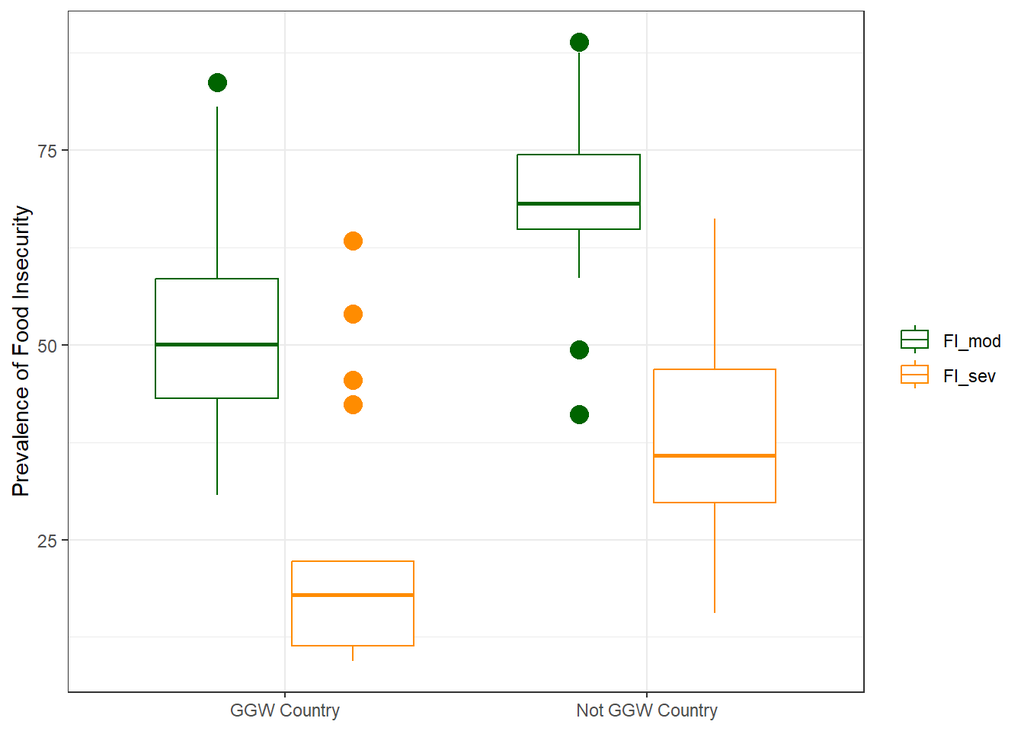

## Visualising LULC in GGW and not GGW countries

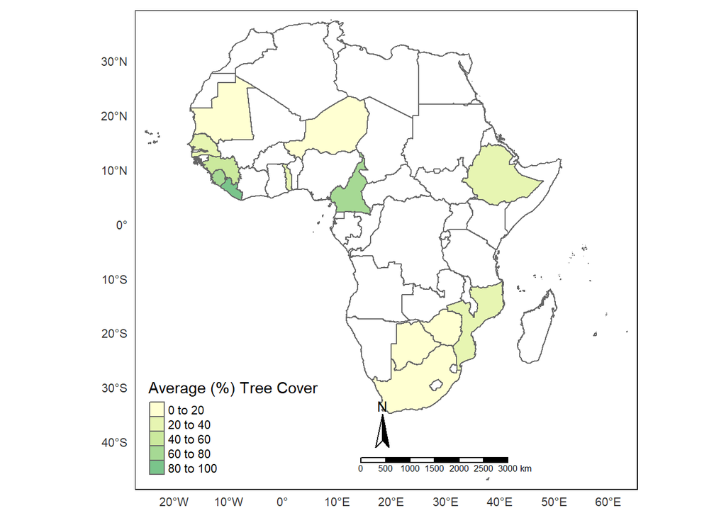

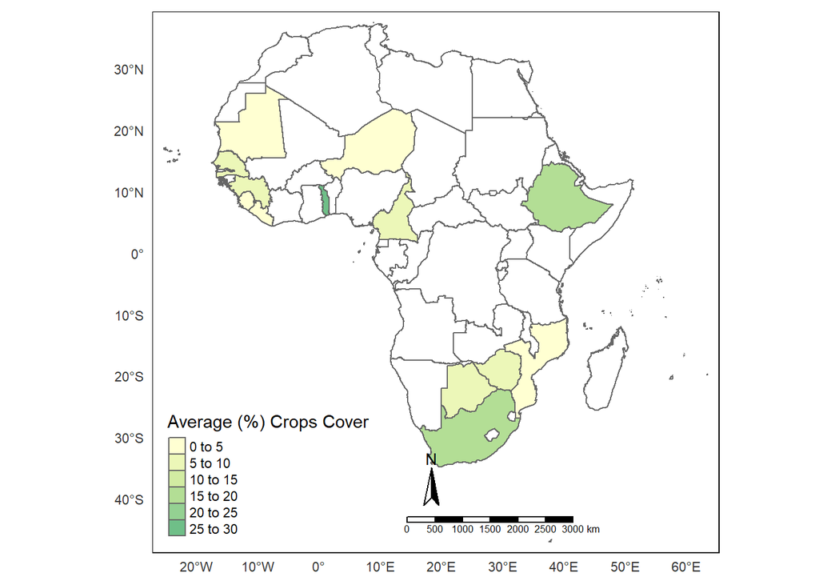

## t test of the food insecurity prevalences

```
##
##  F test to compare two variances
##
## data:  fi.mod.aggw and fi.mod.naggw
## F = 2.1046, num df = 19, denom df = 44, p-value = 0.04251
## alternative hypothesis: true ratio of variances is not equal to 1
## 95 percent confidence interval:
##  1.025398 4.874100
## sample estimates:
## ratio of variances
##           2.104614
```

```
##
##  Welch Two Sample t-test
##
## data:  value by aggwi
## t = -4.649, df = 27.345, p-value = 7.612e-05
## alternative hypothesis: true difference in means between group GGW Country and group Not GGW Country is not equal to 0
## 95 percent confidence interval:
##  -24.53009  -9.51382
## sample estimates:
##     mean in group GGW Country mean in group Not GGW Country
##                      53.64550                      70.66746
```

```
##
##  F test to compare two variances
##
## data:  fi.sev.aggw and fi.sev.naggw
## F = 1.7783, num df = 19, denom df = 44, p-value = 0.1164
## alternative hypothesis: true ratio of variances is not equal to 1
## 95 percent confidence interval:
##  0.8664117 4.1183779
## sample estimates:
## ratio of variances
##           1.778297
```

```
##
##  Two Sample t-test
##
## data:  value by aggwi
## t = -4.7614, df = 63, p-value = 1.167e-05
## alternative hypothesis: true difference in means between group GGW Country and group Not GGW Country is not equal to 0
## 95 percent confidence interval:
##  -23.98097  -9.80229
## sample estimates:
##     mean in group GGW Country mean in group Not GGW Country
##                      22.49263                      39.38426
```

The Welch t-test performed for moderate FI and the classical t-test performed for severe FI confirm a significant difference of means of moderate and severe FI between GGW countries and not GGW countries.

Can we attribute the observed lower average moderate FI and severe FI in GGW countries compared to other African countries not part of the initiative to the GGW-induced land use and land cover change? The panel data regression can help test this hypothesis.

# Panel data regression

## Number of observations

```r
# number of observations by country
blc_panel %>%
  group_by(country) %>%
  summarise(n = n())
```

| country | n |
| --- | --- |
| Botswana | 6 |
| Cameroon | 6 |
| Ethiopia | 6 |
| Guinea | 6 |
| Liberia | 6 |
| Mauritania | 6 |
| Mozambique | 6 |
| Niger | 6 |
| Senegal | 6 |
| Sierra Leone | 6 |

[output cut: 3 more lines]

```r
# number of observations by year
blc_panel %>%
  group_by(year) %>%
  summarise(n = n())
```

| year | n |
| --- | --- |
| 2015 | 13 |
| 2016 | 13 |
| 2017 | 13 |
| 2018 | 13 |
| 2019 | 13 |
| 2020 | 13 |

## Overall variations

This shows the overall variation across countries and over time.

```
##
## ====================================
## Statistic   N  St. Dev.  Min    Max
## ------------------------------------
## FI_mod      78  13.96   -34.39 23.78
## FI_sev      78  14.54   -24.01 32.84
## trees       78  31.90   -33.01 65.56
## crops       78   7.83   -8.23  30.92
## bare        78  32.18   -20.10 76.09
## spi.mean    78   0.53   -1.76  1.00
## spi.min     78   0.88   -3.31  1.62
## spi.max     78   0.49   -0.90  1.29
## rdri.mean   78   0.52   -0.99  0.84
## aggwi       78   0.46   -0.31  0.69
## wgi         78   0.51   -0.71  1.25
## hdi         78   0.10   -0.16  0.20
## health      78   0.04   -0.08  0.10
## educational 78   0.14   -0.24  0.29
## income      78   0.12   -0.14  0.26
## fsi         78  11.70   -31.68 16.15
## ------------------------------------
```

## Between variations

This show variation between countries, i.e. from one country to the other.

```
##
## ==========================================
## Statistic   N  Mean  St. Dev.  Min   Max
## ------------------------------------------
## FI_mod      13 65.14  13.55   42.32 85.75
## FI_sev      13 33.42  13.37   11.84 56.81
## trees       13 33.04  32.57   0.06  96.60
## crops       13 8.29    7.49   1.16  26.62
## bare        13 20.10  33.14   0.02  93.45
## spi.mean    13 -0.15   0.32   -0.71  0.45
## spi.min     13 -1.15   0.65   -2.53 -0.31
## spi.max     13 0.74    0.29   0.01   0.97
## rdri.mean   13 0.99    0.12   0.80   1.23
## aggwi       13 0.31    0.48     0     1
## wgi         13 -0.72   0.52   -1.35  0.38
## hdi         13 0.53    0.10   0.39   0.72
## health      13 0.65    0.04   0.60   0.74
## educational 13 0.46    0.15   0.25   0.74
## income      13 0.51    0.13   0.38   0.76
## fsi         13 88.75  11.89   61.44 101.55
## ------------------------------------------
```

## Within variations

Shows variation within countries.

```
##
## ====================================
## Statistic   N  St. Dev.  Min    Max
## ------------------------------------
## FI_mod      78   4.83   -16.85 9.30
## FI_sev      78   6.65   -23.25 17.87
## trees       78   5.08   -10.01 27.19
## crops       78   2.97   -7.24  12.59
## bare        78   2.90   -8.80  12.94
## spi.mean    78   0.43   -1.40  0.80
## spi.min     78   0.61   -2.28  1.16
## spi.max     78   0.40   -1.03  1.15
## rdri.mean   78   0.51   -0.99  0.93
## aggwi       78   0.00     0      0
## wgi         78   0.09   -0.23  0.33
## hdi         78   0.01   -0.02  0.02
## health      78   0.01   -0.03  0.02
## educational 78   0.01   -0.02  0.02
## income      78   0.01   -0.02  0.02
## fsi         78   2.16   -5.47  4.07
## ------------------------------------
```

This shows that there’s much more variability between each country than within each country’s repeated measures regarding the FI_mod and FI_sev.

## Pooled OLS for all countries

```r
# Pooled OLS, between, and first differences estimator --------------------


# Pooled OLS estimator for moderate
ols_mod <- plm(formula = log(FI_mod) ~ trees + crops + log(hdi) + rdri.mean + wgi + aggwi,
              data = blc_panel_1 ,
              index = c("country", "year"), # c(group index, time index)
              model = "pooling")

#summary(ols_mod)
# Pooled OLS estimator for severe FI
ols_sev <- plm(formula = log(FI_sev) ~ trees + crops + log(hdi) + rdri.mean + wgi + aggwi,
              data = blc_panel_1 ,
              index = c("country", "year"), # c(group index, time index)
              model = "pooling")
#summary(ols_sev)
```

## Pooled OLS for GGW initiative countries

```r
# Pooled OLS estimator for moderate
ols_mod_2 <- plm(formula = log(FI_mod) ~ trees + crops + log(hdi) + rdri.mean + wgi,
              data = aggwi_blc_panel_1 ,
              index = c("country", "year"), # c(group index, time index)
              model = "pooling")

#summary(ols_mod_2)

# Pooled OLS estimator for severe FI
ols_sev_2 <- plm(formula = log(FI_sev) ~ trees + crops + log(hdi) + rdri.mean + wgi,
              data = aggwi_blc_panel_1 ,
              index = c("country", "year"), # c(group index, time index)
              model = "pooling")
```

## Between estimator

```
## Oneway (individual) effect Between Model
##
## Call:
## plm(formula = log(FI_sev) ~ trees + crops + log(hdi) + rdri.mean +
##     wgi + aggwi, data = blc_panel_1, model = "between", index = c("country",
##     "year"))
##
## Balanced Panel: n = 13, T = 5, N = 65
## Observations used in estimation: 13
##
## Residuals:
##      Min.   1st Qu.    Median   3rd Qu.      Max.
## -0.321802 -0.139842 -0.010633  0.108051  0.359869
##
## Coefficients:
##                Estimate  Std. Error t-value Pr(>|t|)
## (Intercept)  4.29895643  1.43820978  2.9891  0.02435 *
## trees       -0.00010509  0.00346872 -0.0303  0.97681
## crops       -0.01686701  0.01447270 -1.1654  0.28807
## log(hdi)    -1.61041984  0.79546503 -2.0245  0.08934 .
## rdri.mean   -1.02274276  1.22381518 -0.8357  0.43533
## wgi          0.35530650  0.30179638  1.1773  0.28365
## aggwi       -1.12909742  0.30624235 -3.6869  0.01025 *
## ---
## Signif. codes:  0 '***' 0.001 '**' 0.01 '*' 0.05 '.' 0.1 ' ' 1
##
## Total Sum of Squares:    2.9719
## Residual Sum of Squares: 0.49417
## R-Squared:      0.83372
## Adj. R-Squared: 0.66744
## F-statistic: 5.01394 on 6 and 6 DF, p-value: 0.035271
```

## First Differences estimator

Takes the difference between the value of a given year and that of the previous year to estimate the model.

```
##
## Call:
## lm(formula = dFI_sev ~ dtrees + dcrops, data = blc_panel)
##
## Residuals:
##      Min       1Q   Median       3Q      Max
## -26.7097  -4.8938   0.3266   5.1158  19.8394
##
## Coefficients:
##              Estimate Std. Error t value Pr(>|t|)
## (Intercept)  0.983584   1.146792   0.858    0.394
## dtrees      -0.299129   0.173118  -1.728    0.089 .
## dcrops      -0.007871   0.238496  -0.033    0.974
## ---
## Signif. codes:  0 '***' 0.001 '**' 0.01 '*' 0.05 '.' 0.1 ' ' 1
##
## Residual standard error: 9.156 on 62 degrees of freedom
##   (13 observations deleted due to missingness)
## Multiple R-squared:  0.04873,    Adjusted R-squared:  0.01804
## F-statistic: 1.588 on 2 and 62 DF,  p-value: 0.2125
```

## Fixed effects within estimator

```r
# Fixed effects within estimator

fe_sev <- update(ols_sev, model = "within", effect = "individual")

summary(fe_sev)
```

```
## Oneway (individual) effect Within Model
##
## Call:
## plm(formula = log(FI_sev) ~ trees + crops + log(hdi) + rdri.mean +
##     wgi + aggwi, data = blc_panel_1, effect = "individual", model = "within",
##     index = c("country", "year"))
##
## Balanced Panel: n = 13, T = 5, N = 65
##
## Residuals:
##      Min.   1st Qu.    Median   3rd Qu.      Max.
## -0.426840 -0.097391  0.027514  0.094718  0.297086
##
## Coefficients:
##            Estimate Std. Error t-value  Pr(>|t|)
## trees     0.0047157  0.0049286  0.9568   0.34356
## crops     0.0119164  0.0081520  1.4618   0.15046
## log(hdi)  7.9882151  1.8345538  4.3543 7.173e-05 ***
## rdri.mean 0.2160491  0.0801624  2.6951   0.00973 **
## wgi       0.8954889  0.3456993  2.5904   0.01273 *
## ---
## Signif. codes:  0 '***' 0.001 '**' 0.01 '*' 0.05 '.' 0.1 ' ' 1
##
## Total Sum of Squares:    2.5941
## Residual Sum of Squares: 1.5857
## R-Squared:      0.38873
## Adj. R-Squared: 0.16763
## F-statistic: 5.97783 on 5 and 47 DF, p-value: 0.00023371
```

```r
# Summarize the individual specific effects a_i
ai <- fixef(fe_sev, type = "dmean") # extract fixed effects using 'fixef'
ai
```

```
##     Botswana     Cameroon     Ethiopia       Guinea      Liberia   Mauritania
##    -3.261553    -0.619214    -0.447272     1.602289     1.541349    -0.634983
##   Mozambique        Niger      Senegal Sierra Leone South Africa         Togo
##     1.782914     2.955980    -0.851139     1.887307    -3.508945    -0.026916
##     Zimbabwe
##    -0.419819
```

```r
summary(ai) # 'summary' shows the p-value table
```

```
##               Estimate Std. Error t-value  Pr(>|t|)
## Botswana     -3.261553   0.600494 -5.4314 1.930e-06 ***
## Cameroon     -0.619214   0.965052 -0.6416   0.52423
## Ethiopia     -0.447272   1.302423 -0.3434   0.73282
## Guinea        1.602289   1.376810  1.1638   0.25039
## Liberia       1.541349   1.290805  1.1941   0.23843
## Mauritania   -0.634983   1.098500 -0.5780   0.56599
## Mozambique    1.782914   1.432095  1.2450   0.21931
## Niger         2.955980   1.707688  1.7310   0.09002 .
## Senegal      -0.851139   1.171153 -0.7268   0.47098
## Sierra Leone  1.887307   1.332141  1.4167   0.16315
## South Africa -3.508945   0.568406 -6.1733 1.471e-07 ***
## Togo         -0.026916   1.180524 -0.0228   0.98191
## Zimbabwe     -0.419819   1.003819 -0.4182   0.67769
## ---
## Signif. codes:  0 '***' 0.001 '**' 0.01 '*' 0.05 '.' 0.1 ' ' 1
```

```r
data.frame(ai) %>% stargazer(type = "text") # summarize
```

```
##
## =========================================
## Statistic N   Mean  St. Dev.  Min    Max
## -----------------------------------------
## ai        13 -0.000  1.942   -3.509 2.956
## -----------------------------------------
```

```r
#
# stargazer(summary(ai), type = "html", title="Unobserved Effect (Moderate FI)",
#           out= "Unobs_mod.html")
```

## Random effects estimator

```r
# Random effects estimator

re_sev <- update(ols_sev, model = "random", random.method = "walhus")

summary(re_sev)
```

```
## Oneway (individual) effect Random Effect Model
##    (Wallace-Hussain's transformation)
##
## Call:
## plm(formula = log(FI_sev) ~ trees + crops + log(hdi) + rdri.mean +
##     wgi + aggwi, data = blc_panel_1, model = "random", random.method = "walhus",
##     index = c("country", "year"))
##
## Balanced Panel: n = 13, T = 5, N = 65
##
## Effects:
##                   var std.dev share
## idiosyncratic 0.06279 0.25058 0.672
## individual    0.03064 0.17503 0.328
## theta: 0.4608
##
## Residuals:
##      Min.   1st Qu.    Median   3rd Qu.      Max.
## -0.603024 -0.187263  0.019253  0.202368  0.699716
##
## Coefficients:
##                Estimate  Std. Error z-value  Pr(>|z|)
## (Intercept)  3.11912667  0.29421308 10.6016 < 2.2e-16 ***
## trees       -0.00087362  0.00242658 -0.3600  0.718831
## crops       -0.00968199  0.00689506 -1.4042  0.160262
## log(hdi)    -1.44465558  0.54546759 -2.6485  0.008086 **
## rdri.mean   -0.08895947  0.08566245 -1.0385  0.299043
## wgi          0.18267579  0.17079560  1.0696  0.284818
## aggwi       -0.96390035  0.17369559 -5.5494 2.867e-08 ***
## ---
## Signif. codes:  0 '***' 0.001 '**' 0.01 '*' 0.05 '.' 0.1 ' ' 1
##
## Total Sum of Squares:    6.9143
## Residual Sum of Squares: 3.9631
## R-Squared:      0.42683
## Adj. R-Squared: 0.36754
## Chisq: 43.1922 on 6 DF, p-value: 1.0686e-07
```

```r
# The theta parameter is listed in the summary

# Calculate the random effects parameter theta
(sigma2_e <- re_sev$ercomp$sigma2["idios"])
```

```
##     idios
## 0.0627922
```

```r
(sigma2_u <- re_sev$ercomp$sigma2["id"])
```

```
##         id
## 0.03063699
```

```r
(theta <- 1 - sqrt(sigma2_e / (sigma2_e + 3*sigma2_u)))
```

```
##     idios
## 0.3629064
```

## Hausman test for fixed versus random effects

The Hausman test is used to decide whether to use fixed effects or random effects.

- H0: FE coefficients are not significantly different from the RE coefficients
- Ha: FE coefficients are significantly different from the RE coefficients

```r
# Fixed effects estimator
summary(fe_sev)
```

```
## Oneway (individual) effect Within Model
##
## Call:
## plm(formula = log(FI_sev) ~ trees + crops + log(hdi) + rdri.mean +
##     wgi + aggwi, data = blc_panel_1, effect = "individual", model = "within",
##     index = c("country", "year"))
##
## Balanced Panel: n = 13, T = 5, N = 65
##
## Residuals:
##      Min.   1st Qu.    Median   3rd Qu.      Max.
## -0.426840 -0.097391  0.027514  0.094718  0.297086
##
## Coefficients:
##            Estimate Std. Error t-value  Pr(>|t|)
## trees     0.0047157  0.0049286  0.9568   0.34356
## crops     0.0119164  0.0081520  1.4618   0.15046
## log(hdi)  7.9882151  1.8345538  4.3543 7.173e-05 ***
## rdri.mean 0.2160491  0.0801624  2.6951   0.00973 **
## wgi       0.8954889  0.3456993  2.5904   0.01273 *
## ---
## Signif. codes:  0 '***' 0.001 '**' 0.01 '*' 0.05 '.' 0.1 ' ' 1
##
## Total Sum of Squares:    2.5941
## Residual Sum of Squares: 1.5857
## R-Squared:      0.38873
## Adj. R-Squared: 0.16763
## F-statistic: 5.97783 on 5 and 47 DF, p-value: 0.00023371
```

```r
# Random effects estimator
summary(re_sev)
```

```
## Oneway (individual) effect Random Effect Model
##    (Wallace-Hussain's transformation)
##
## Call:
## plm(formula = log(FI_sev) ~ trees + crops + log(hdi) + rdri.mean +
##     wgi + aggwi, data = blc_panel_1, model = "random", random.method = "walhus",
##     index = c("country", "year"))
##
## Balanced Panel: n = 13, T = 5, N = 65
##
## Effects:
##                   var std.dev share
## idiosyncratic 0.06279 0.25058 0.672
## individual    0.03064 0.17503 0.328
## theta: 0.4608
##
## Residuals:
##      Min.   1st Qu.    Median   3rd Qu.      Max.
## -0.603024 -0.187263  0.019253  0.202368  0.699716
##
## Coefficients:
##                Estimate  Std. Error z-value  Pr(>|z|)
## (Intercept)  3.11912667  0.29421308 10.6016 < 2.2e-16 ***
## trees       -0.00087362  0.00242658 -0.3600  0.718831
## crops       -0.00968199  0.00689506 -1.4042  0.160262
## log(hdi)    -1.44465558  0.54546759 -2.6485  0.008086 **
## rdri.mean   -0.08895947  0.08566245 -1.0385  0.299043
## wgi          0.18267579  0.17079560  1.0696  0.284818
## aggwi       -0.96390035  0.17369559 -5.5494 2.867e-08 ***
## ---
## Signif. codes:  0 '***' 0.001 '**' 0.01 '*' 0.05 '.' 0.1 ' ' 1
##
## Total Sum of Squares:    6.9143
## Residual Sum of Squares: 3.9631
## R-Squared:      0.42683
## Adj. R-Squared: 0.36754
## Chisq: 43.1922 on 6 DF, p-value: 1.0686e-07
```

```r
# Hausman test for fixed versus random effects
phtest(fe_sev, re_sev)
```

```
##
##  Hausman Test
##
## data:  log(FI_sev) ~ trees + crops + log(hdi) + rdri.mean + wgi + aggwi
## chisq = 75.641, df = 5, p-value = 6.837e-15
## alternative hypothesis: one model is inconsistent
```

```r
# If the Hausman test statistic is insignificant, use RE estimator because it is efficient
# If the Hausman test statistic is significant, use FE estimator because it is consistent
```

The Hausman Test statistic is significant. Therefore the Fixed Effect estimator could be a better option.

I am trying the time-varying FE estimator to see if I get any meaningful results.

## Time-varying Fixed Effect model

```r
# Time-varying FE model with tvReg package



tv_fe <- tvPLM(formula = FI_sev ~ trees + crops + hdi + spi.min,
               data = blc_panel ,
               index = c("country","year"),
               method = "within", bw = 0.8)
summary(tv_fe)
```

```
##
## Call:
## tvPLM(formula = FI_sev ~ trees + crops + hdi + spi.min, data = blc_panel,
##     index = c("country", "year"), bw = 0.8, method = "within")
##
## Class:  tvplm
##
## Summary of time-varying estimated coefficients:
## ================================================
##           trees    crops   hdi spi.min
## Min.    -0.4412 -0.17961 78.26 -3.3510
## 1st Qu. -0.3462 -0.10771 78.92 -2.9117
## Median  -0.2919  0.03207 80.74 -1.5984
## Mean    -0.3192  0.01440 81.39 -1.0189
## 3rd Qu. -0.2727  0.12651 83.08  0.7624
## Max.    -0.2596  0.19820 86.43  2.2344
##
## Bandwidth:  0.8
## Pseudo R-squared:  -1.8856
```

```r
#tv_fe$coefficients

print(tv_fe)
```

```
##
## Class:  tvplm
##
## Mean of coefficient estimates:
## ===============================
##   trees   crops     hdi spi.min
## -0.3192  0.0144 81.3905 -1.0189
##
## Bandwidth:  0.8
```

```r
# Time-varying FE model with tvReg package


tv_fe <- tvPLM(formula = FI_mod ~ trees + crops + hdi,
               data = blc_panel ,
               index = c("country","year"),
               bw = 0.8,
               method = "within")
summary(tv_fe)
```

```
##
## Call:
## tvPLM(formula = FI_mod ~ trees + crops + hdi, data = blc_panel,
##     index = c("country", "year"), bw = 0.8, method = "within")
##
## Class:  tvplm
##
## Summary of time-varying estimated coefficients:
## ================================================
##              trees    crops   hdi
## Min.    -0.0787974 -0.36743 127.2
## 1st Qu. -0.0550636 -0.30813 127.6
## Median  -0.0170546 -0.25661 127.9
## Mean    -0.0271837 -0.24277 128.3
## 3rd Qu.  0.0002881 -0.18171 128.8
## Max.     0.0114687 -0.09394 130.3
##
## Bandwidth:  0.8
## Pseudo R-squared:  -1.294
```

```r
tv_fe$coefficients
```

```
##             trees       crops      hdi
## [1,] -0.018002725 -0.36743211 129.0323
## [2,]  0.005753028 -0.31792307 127.7120
## [3,]  0.011468734 -0.27876455 127.1888
## [4,] -0.016106550 -0.23446091 128.1098
## [5,] -0.078797377 -0.16412092 130.2655
## [6,] -0.067417215 -0.09393921 127.6213
```

```r
print(tv_fe)
```

```
##
## Class:  tvplm
##
## Mean of coefficient estimates:
## ===============================
##     trees     crops       hdi
##  -0.02718  -0.24277 128.32163
##
## Bandwidth:  0.8
```

For relatively constant predictors or those that change slowly over time, the fixed effect specification tends to produce odd estimates since the specification is used precisely to control for factors that do not vary over time (Beck, 2001; Lenaerts and Demont, 2021). The argument is particularly valid for geography-related variables, such as the predictor variables of interest in this study (land use and land cover) which are known to be slow changing variables. Therefore I am choosing a pooled OLS with time dummies.

## Pooled OLS with time dummies

I ran a simple time invariance test for each independent variable with country dummies. High R^2 suggest that the variable do not vary much across countries and therefore its effect can will not be captured by a fixed effect specification. The code bellow show how I ran the test but I will not include the output.

```r
# time invariance test by regressing each variable with country dummies

tiv <- plm(formula = income ~  factor(country),
              data = blc_panel_1 ,
              index = c("country", "year"), # c(group index, time index)
              model = "pooling")
#summary(tiv)
```

```r
# Dummy variables regression

# Dummy variables regression with fixed effects
dv_mod <- update(ols_mod, ~ . + factor(year))

dv_mod_2 <- update(ols_mod_2, ~ . + factor(year))


dv_sev <- update(ols_sev, ~ . + factor(year))

dv_sev_2 <- update(ols_sev_2, ~ . + factor(year))
# factor(year) creates one dummy variable for each year

summary(dv_mod)
```

```
## Pooling Model
##
## Call:
## plm(formula = log(FI_mod) ~ trees + crops + log(hdi) + rdri.mean +
##     wgi + aggwi + factor(year), data = blc_panel_1, model = "pooling",
##     index = c("country", "year"))
##
## Balanced Panel: n = 13, T = 5, N = 65
##
## Residuals:
##      Min.   1st Qu.    Median   3rd Qu.      Max.
## -0.295003 -0.094043  0.022923  0.077802  0.284579
##
## Coefficients:
##                     Estimate  Std. Error t-value  Pr(>|t|)
## (Intercept)       3.59625700  0.14195900 25.3331 < 2.2e-16 ***
## trees             0.00055013  0.00075378  0.7298   0.46864
## crops            -0.00371636  0.00246172 -1.5097   0.13696
## log(hdi)         -0.78595112  0.16843391 -4.6662 2.064e-05 ***
## rdri.mean         0.07638786  0.08144872  0.9379   0.35249
## wgi               0.04225669  0.05440674  0.7767   0.44074
## aggwi            -0.38676697  0.05346637 -7.2338 1.718e-09 ***
## factor(year)2016  0.10791955  0.05672915  1.9024   0.06246 .
## factor(year)2017  0.14853579  0.05647039  2.6303   0.01109 *
## factor(year)2018  0.13866421  0.05664772  2.4478   0.01765 *
## factor(year)2019  0.22463340  0.08534927  2.6319   0.01105 *
## ---
## Signif. codes:  0 '***' 0.001 '**' 0.01 '*' 0.05 '.' 0.1 ' ' 1
##
## Total Sum of Squares:    3.6391
## Residual Sum of Squares: 1.1021
## R-Squared:      0.69716
## Adj. R-Squared: 0.64107
## F-statistic: 12.4309 on 10 and 54 DF, p-value: 7.7874e-11
```

```r
#summary(dv_mod_2)

# Dummy variables regression with fixed effects
#dv_sev_spi <- update(ols_sev_spi, ~ . + factor(year))
summary(dv_sev)
```

```
## Pooling Model
##
## Call:
## plm(formula = log(FI_sev) ~ trees + crops + log(hdi) + rdri.mean +
##     wgi + aggwi + factor(year), data = blc_panel_1, model = "pooling",
##     index = c("country", "year"))
##
## Balanced Panel: n = 13, T = 5, N = 65
##
## Residuals:
##       Min.    1st Qu.     Median    3rd Qu.       Max.
## -0.6160500 -0.1891590  0.0068398  0.1476320  0.8211825
##
## Coefficients:
##                     Estimate  Std. Error t-value  Pr(>|t|)
## (Intercept)       2.63051028  0.28739819  9.1528 1.425e-12 ***
## trees            -0.00036348  0.00152603 -0.2382 0.8126399
## crops            -0.02049463  0.00498379 -4.1123 0.0001344 ***
## log(hdi)         -1.49309939  0.34099706 -4.3786 5.523e-05 ***
## rdri.mean         0.10453709  0.16489420  0.6340 0.5287804
## wgi               0.19826454  0.11014729  1.8000 0.0774486 .
## aggwi            -0.94846393  0.10824349 -8.7623 5.919e-12 ***
## factor(year)2016  0.25969725  0.11484905  2.2612 0.0277977 *
## factor(year)2017  0.44341358  0.11432519  3.8785 0.0002874 ***
## factor(year)2018  0.37382307  0.11468419  3.2596 0.0019339 **
## factor(year)2019  0.49588400  0.17279091  2.8699 0.0058514 **
## ---
## Signif. codes:  0 '***' 0.001 '**' 0.01 '*' 0.05 '.' 0.1 ' ' 1
##
## Total Sum of Squares:    17.454
## Residual Sum of Squares: 4.517
## R-Squared:      0.7412
## Adj. R-Squared: 0.69327
## F-statistic: 15.4656 on 10 and 54 DF, p-value: 1.4109e-12
```

```r
#summary(dv_sev_2)
```

## Testing for heteroskedasticity

```r
library(sandwich)
library(lmtest)

# The null hypothesis for the Breusch-Pagan test is homoskedasticity

bptest(formula = log(FI_mod) ~ trees + crops + log(hdi) + rdri.mean + wgi +  factor(year),
              data = blc_panel_1 , studentize=F)

bptest(formula = log(FI_sev) ~ trees + crops + log(hdi) + rdri.mean + wgi +  factor(year),
              data = blc_panel_1 , studentize=F)
```

[output not shown]

```r
# calculating clustered standard errors


se.dvmod <- coeftest(dv_mod,
                     vcov=vcovHC(dv_mod,type="HC1",cluster="group"))
se.dvsev <- coeftest(dv_sev,
                    vcov=vcovHC(dv_sev,type="HC1",cluster="group"))

# se.dv_mod_t <- coeftest(dv_mod_t,
#                     vcov=vcovHC(dv_mod_t,type="HC1",cluster="group"))
#
#    #--------------------------------------------
# se.dv_mod_c <- coeftest(dv_mod_c,
#                           vcov=vcovHC(dv_mod_c,type="HC1",cluster="group"))
#
#     #-----------------------------------------------
#
# se.dv_sev_t <- coeftest(dv_sev_t,
#                     vcov=vcovHC(dv_sev_t,type="HC1",cluster="group"))
#
#      #--------------------------------------------
# se.dv_sev_c <- coeftest(dv_sev_c,
#                     vcov=vcovHC(dv_sev_c,type="HC1",cluster="group"))
#se.dvmod[, 2]
```

```
##
## ================================================================
##                   Moderate Food Insecuri  Severe Food Insecurity
##                   ----------------------  ----------------------
##                   MM1         MM2         MS1         MS2
## ----------------------------------------------------------------
## (Intercept)        3.596 ***   1.855 ***   2.631 ***   0.695
##                   (0.212)     (0.348)     (0.356)     (0.682)
## trees              0.001      -0.001      -0.000      -0.000
##                   (0.001)     (0.005)     (0.003)     (0.010)
## crops             -0.004      -0.000      -0.020 *    -0.064 **
##                   (0.002)     (0.009)     (0.009)     (0.018)
## log(hdi)          -0.786 *    -1.705 ***  -1.493 *    -2.524 ***
##                   (0.384)     (0.189)     (0.737)     (0.370)
## rdri.mean          0.076       0.312       0.105       0.328
##                   (0.059)     (0.167)     (0.136)     (0.327)
## wgi                0.042      -0.289       0.198       0.172
##                   (0.095)     (0.214)     (0.100)     (0.419)
## aggwi             -0.387 **               -0.948 ***
##                   (0.120)                 (0.216)
## factor(year)2016   0.108 **    0.346 **    0.260 ***   0.444 *
##                   (0.037)     (0.081)     (0.063)     (0.158)
## factor(year)2017   0.149 **    0.329 **    0.443 ***   0.671 **
##                   (0.050)     (0.083)     (0.077)     (0.164)
## factor(year)2018   0.139 **    0.332 **    0.374 **    0.811 **
##                   (0.047)     (0.096)     (0.129)     (0.188)
## factor(year)2019   0.225 **    0.657 **    0.496 ***   1.103 **
##                   (0.067)     (0.175)     (0.130)     (0.342)
## ----------------------------------------------------------------
## R^2                0.697       0.925       0.741       0.940
## Adj. R^2           0.641       0.858       0.693       0.886
## Num. obs.         65          20          65          20
## ================================================================
## *** p < 0.001; ** p < 0.01; * p < 0.05
```

## Oster bounds robustness check

I am using the robomit package developped by Schaub, S. (2021) using the framework developped by Oster, (2019).

### β∗: the bias-adjusted treatment effect

```r
library(robomit)


# beta star for the effect of tree cover on moderate FI
bs_mod_t <- o_beta(y = "FI_mod", x = "trees",
                      con = "crops + log(hdi) + rdri.mean + wgi + factor(year)",
                      id = "country", time = "year", R2max = 1.3*0.69,
                      type = "lm", data = blc_panel_1)

bs_mod_t
```

| Name | Value |
| --- | --- |
| beta* | -0.2385170 |
| (beta*-beta controlled)^2 | 0.1767330 |
| Alternative Solution 1 | 0.4843780 |
| (beta[AS1]-beta controlled)^2 | 0.0915050 |
| Uncontrolled Coefficient | 0.2502543 |
| Controlled Coefficient | 0.1818792 |
| Uncontrolled R-square | 0.3172743 |
| Controlled R-square | 0.4658152 |
| Max R-square | 0.8970000 |
| delta | 1.0000000 |

```r
# beta star for the effect of crop cover on moderate FI
bs_mod_c <- o_beta(y = "FI_mod", x = "crops",
                      con = "trees + log(hdi) + rdri.mean + wgi + factor(year)",
                      id = "country", time = "year", R2max = 1.3*0.69,
                      type = "lm", data =  blc_panel_1)

bs_mod_c
```

| Name | Value |
| --- | --- |
| beta* | -0.17122700 |
| (beta*-beta controlled)^2 | 0.04424400 |
| Alternative Solution 1 | -8.15943500 |
| (beta[AS1]-beta controlled)^2 | 60.49517500 |
| Uncontrolled Coefficient | -0.49321479 |
| Controlled Coefficient | -0.38157066 |
| Uncontrolled R-square | 0.08046823 |
| Controlled R-square | 0.46581525 |
| Max R-square | 0.89700000 |
| delta | 1.00000000 |

```r
# beta star for the effect of tree cover on severe FI
bs_sev_t <- o_beta(y = "FI_sev", x = "trees",
                      con = "crops + log(hdi) + rdri.mean + wgi + factor(year)",
                      id = "country", time = "year", R2max = 1.3*0.74,
                      type = "lm", data =  blc_panel_1)

bs_sev_t
```

| Name | Value |
| --- | --- |
| beta* | -0.2201230 |
| (beta*-beta controlled)^2 | 0.1584470 |
| Alternative Solution 1 | 0.6054750 |
| (beta[AS1]-beta controlled)^2 | 0.1827940 |
| Uncontrolled Coefficient | 0.2268219 |
| Controlled Coefficient | 0.1779309 |
| Uncontrolled R-square | 0.2242706 |
| Controlled R-square | 0.4654832 |
| Max R-square | 0.9620000 |
| delta | 1.0000000 |

```r
# beta star for the effect of crop cover on severe FI
bs_sev_c <- o_beta(y = "FI_sev", x = "crops",
                      con = "trees + log(hdi) + rdri.mean + wgi + factor(year)",
                      id = "country", time = "year", R2max = 1.3*0.74,
                      type = "lm", data =  blc_panel_1)

bs_sev_c
```

| Name | Value |
| --- | --- |
| beta* | -0.6797030 |
| (beta*-beta controlled)^2 | 0.0018580 |
| Alternative Solution 1 | -51.5098030 |
| (beta[AS1]-beta controlled)^2 | 2579.3183300 |
| Uncontrolled Coefficient | -0.7356109 |
| Controlled Coefficient | -0.7228127 |
| Uncontrolled R-square | 0.1540206 |
| Controlled R-square | 0.4654832 |
| Max R-square | 0.9620000 |
| delta | 1.0000000 |

### δ∗: the degree of selection on unobservables relative to observables

```r
# visualize delta star for the effect of tree cover on moderate FI
ds_mod_t <- o_delta(y = "FI_mod", x = "trees",
                      con = "crops + log(hdi) + rdri.mean + wgi + factor(year)",
                      id = "country", time = "year", R2max = 1.3*0.69,
                      type = "lm", data =  blc_panel_1)

ds_mod_t
```

| Name | Value |
| --- | --- |
| delta* | 0.6164560 |
| Uncontrolled Coefficient | 0.2502543 |
| Controlled Coefficient | 0.1818792 |
| Uncontrolled R-square | 0.3172743 |
| Controlled R-square | 0.4658152 |
| Max R-square | 0.8970000 |
| beta hat | 0.0000000 |

```r
# visualize delta star for the effect of crop cover on moderate FI
ds_mod_c <- o_delta(y = "FI_mod", x = "crops",
                      con = "trees + log(hdi) + rdri.mean + wgi + factor(year)",
                      id = "country", time = "year", R2max = 1.3*0.69,
                      type = "lm", data =  blc_panel_1)

ds_mod_c
```

| Name | Value |
| --- | --- |
| delta* | 1.46273600 |
| Uncontrolled Coefficient | -0.49321479 |
| Controlled Coefficient | -0.38157066 |
| Uncontrolled R-square | 0.08046823 |
| Controlled R-square | 0.46581525 |
| Max R-square | 0.89700000 |
| beta hat | 0.00000000 |

```r
# visualize delta star for the effect of tree cover on severe FI
ds_sev_t <- o_delta(y = "FI_sev", x = "trees",
                      con = "crops + log(hdi) + rdri.mean + wgi + factor(year)",
                      id = "country", time = "year", R2max = 1.3*0.74,
                      type = "lm", data =  blc_panel_1)

ds_sev_t
```

| Name | Value |
| --- | --- |
| delta* | 0.7003520 |
| Uncontrolled Coefficient | 0.2268219 |
| Controlled Coefficient | 0.1779309 |
| Uncontrolled R-square | 0.2242706 |
| Controlled R-square | 0.4654832 |
| Max R-square | 0.9620000 |
| beta hat | 0.0000000 |

```r
# visualize delta star for the effect of crop cover on severe FI
ds_sev_c <- o_delta(y = "FI_sev", x = "crops",
                      con = "trees + log(hdi) + rdri.mean + wgi + factor(year)",
                      id = "country", time = "year", R2max = 1.3*0.74,
                      type = "lm", data =  blc_panel_1)

ds_sev_c
```

| Name | Value |
| --- | --- |
| delta* | 2.0345450 |
| Uncontrolled Coefficient | -0.7356109 |
| Controlled Coefficient | -0.7228127 |
| Uncontrolled R-square | 0.1540206 |
| Controlled R-square | 0.4654832 |
| Max R-square | 0.9620000 |
| beta hat | 0.0000000 |

### visualization of bootstrapped δ∗

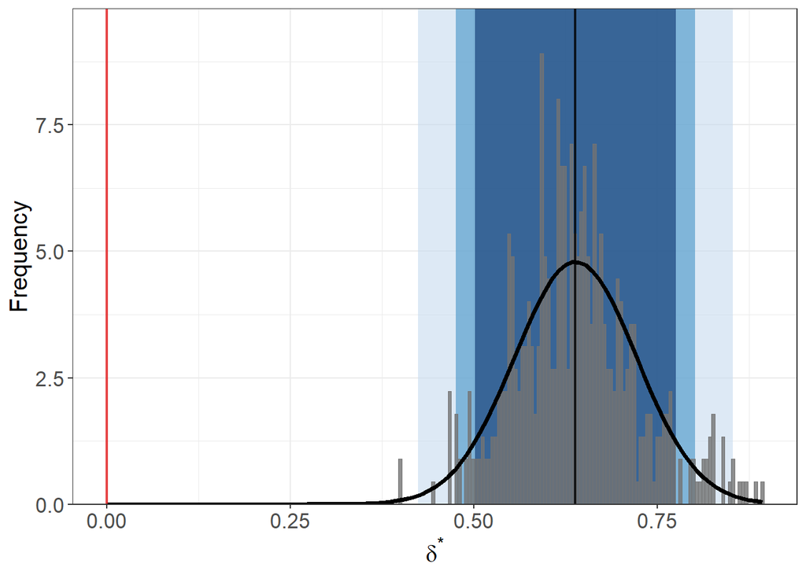

```r
# visualize delta star for the effect of tree cover on moderate FI
vis_ds_mod_t <- o_delta_boot_viz(y = "FI_mod",
                                 x = "trees",
                                 con = "crops + log(hdi) + rdri.mean + wgi + factor(year)",
                                 sim = 500, # number of simulations
                                 obs = 350, # draws per simulation
                                 rep = TRUE, # with replacement
                                 CI = c(90,95,99),
                                 R2max = 1.3*0.69,
                                 type = "lm",
                                 norm = TRUE, # normal distribution
                                 bin = 200, # number of bins
                                 useed = 123, # seed
                                 data =  blc_panel_1)

vis_ds_mod_t
```

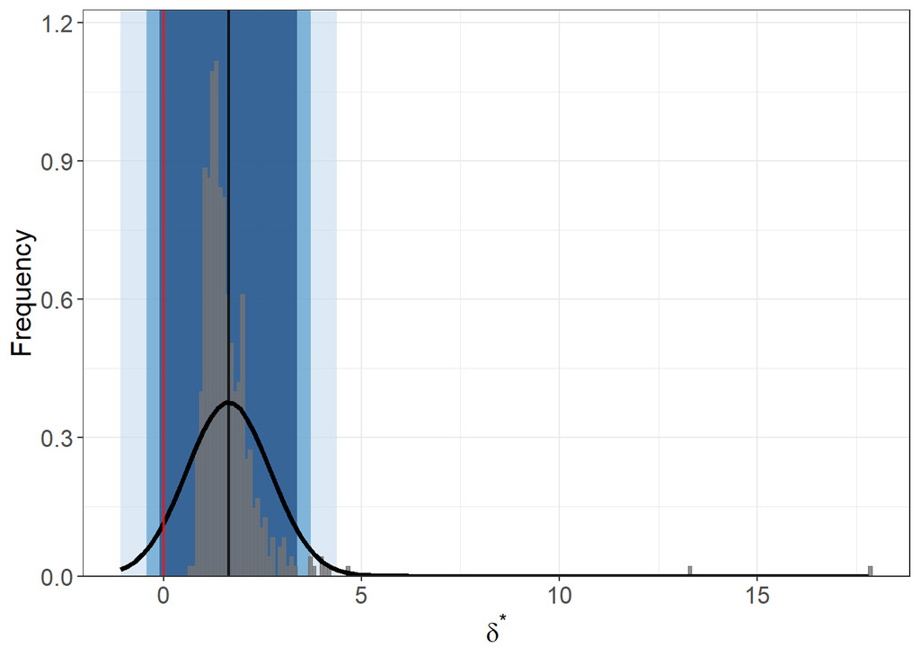

```r
# visualize delta star for the effect of crop cover on moderate FI
vis_ds_mod_c <- o_delta_boot_viz(y = "FI_mod",
                                 x = "crops",
                                 con = "trees + log(hdi) + rdri.mean + wgi + factor(year)",
                                 id = "country", time = "year",
                                 sim = 500, # number of simulations
                                 obs = 350, # draws per simulation
                                 rep = TRUE, # with replacement
                                 CI = c(90,95,99),
                                 R2max = 1.3*0.69,
                                 type = "lm",
                                 norm = TRUE, # normal distribution
                                 bin = 200, # number of bins
                                 useed = 123, # seed
                                 data =  blc_panel_1)

vis_ds_mod_c
```

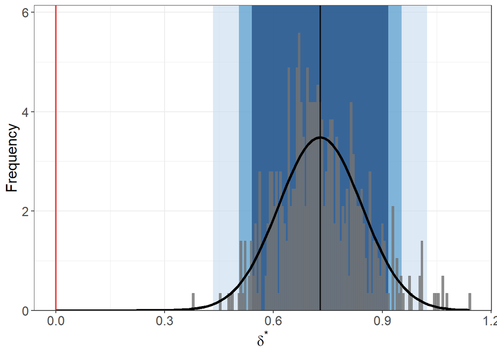

```r
# visualize delta star for the effect of tree cover on severe FI
vis_ds_sev_t <- o_delta_boot_viz(y = "FI_sev", x = "trees",
                                 con = "crops + log(hdi) + rdri.mean + wgi + factor(year)",
                                 id = "country", time = "year",
                                 sim = 500, # number of simulations
                                 obs = 350, # draws per simulation
                                 rep = TRUE, # with replacement
                                 CI = c(90,95,99),
                                 R2max = 1.3*0.74,
                                 type = "lm",
                                 norm = TRUE, # normal distribution
                                 bin = 200, # number of bins
                                 useed = 123, # seed
                                 data =  blc_panel_1)

vis_ds_sev_t
```

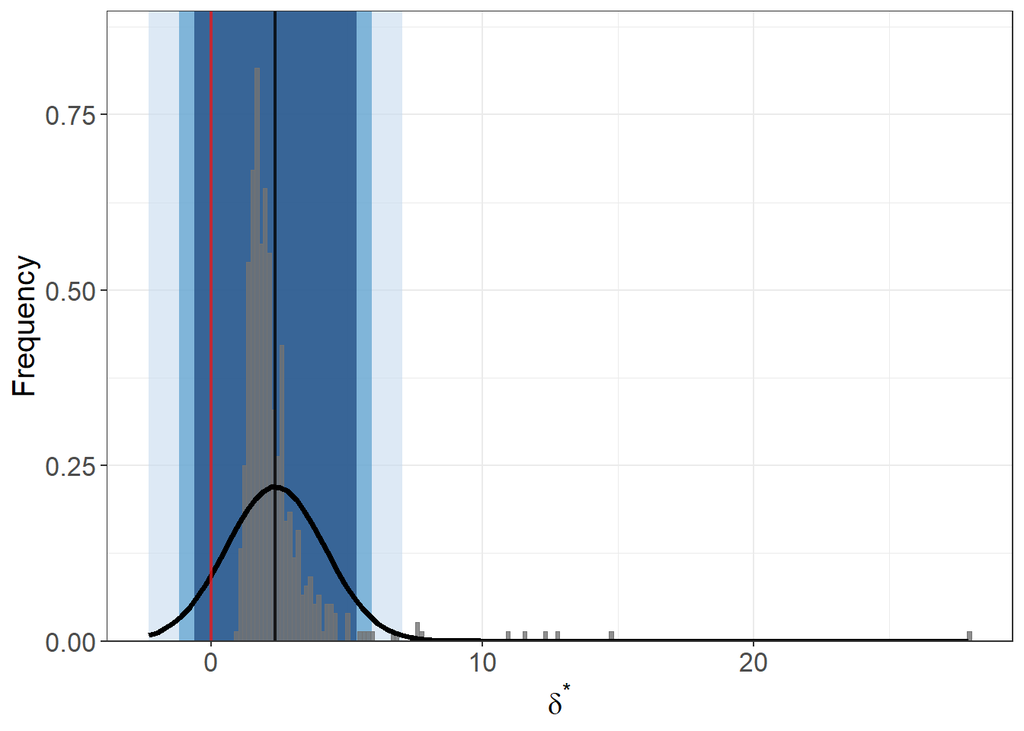

```r
# visualize delta star for the effect of crop cover on severe FI
vis_ds_sev_c <- o_delta_boot_viz(y = "FI_sev", x = "crops",
                                 con = "trees + log(hdi) + rdri.mean + wgi + factor(year)",
                                 id = "country", time = "year",
                                 sim = 500, # number of simulations
                                 obs = 350, # draws per simulation
                                 rep = TRUE, # with replacement
                                 CI = c(90,95,99),
                                 R2max = 1.3*0.74,
                                 type = "lm",
                                 norm = TRUE, # normal distribution
                                 bin = 200, # number of bins
                                 useed = 123, # seed
                                 data =  blc_panel_1)

vis_ds_sev_c
```

### Estimate δ∗ over a range of maximum R-squares

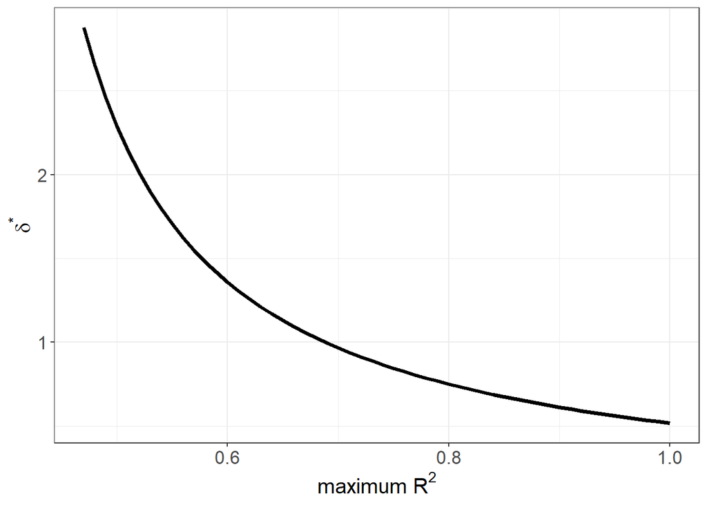

```r
# estimate delta star for the effect of tree cover on moderate FI
es_ds_mod_t <- o_delta_rsq_viz(y = "FI_mod",
                               x = "trees",
                               con = "crops + log(hdi) + rdri.mean + wgi + factor(year)",
                               id = "country", time = "year",
                               type = "lm", data =  blc_panel_1)

es_ds_mod_t
```

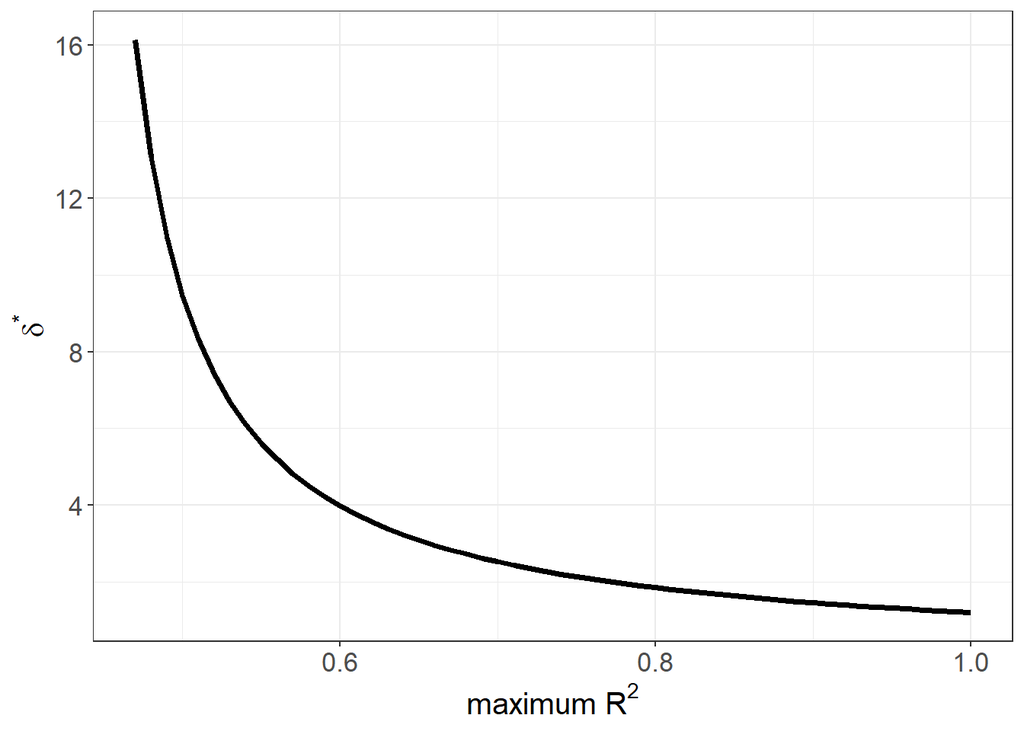

```r
# estimate delta star for the effect of crop cover on moderate FI
es_ds_mod_c <- o_delta_rsq_viz(y = "FI_mod",
                               x = "crops",
                               con = "trees + log(hdi) + rdri.mean + wgi + factor(year)",
                               id = "country", time = "year",
                               type = "lm", data =  blc_panel_1)

es_ds_mod_c
```

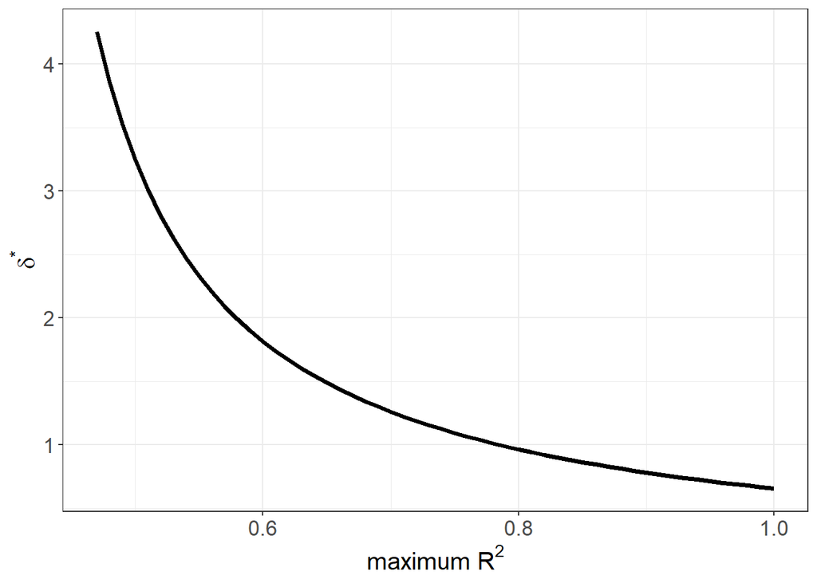

```r
# estimate delta star for the effect of tree cover on severe FI
es_ds_sev_t <- o_delta_rsq_viz(y = "FI_sev",
                               x = "trees",
                               con = "crops + log(hdi) + rdri.mean + wgi + factor(year)",
                               id = "country", time = "year",
                               type = "lm", data =  blc_panel_1)

es_ds_sev_t
```

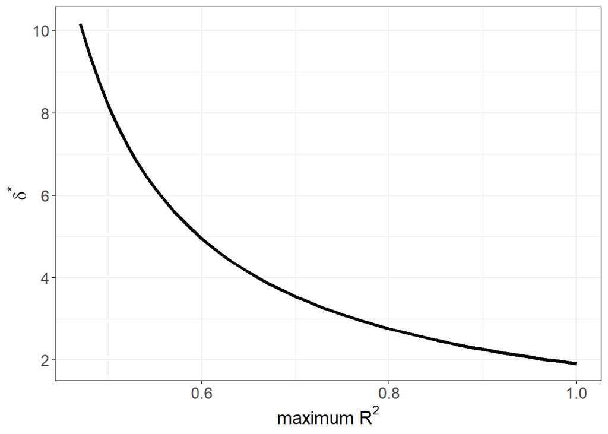

```r
# estimate delta star for the effect of crop cover on severe FI
es_ds_sev_c <- o_delta_rsq_viz(y = "FI_sev",
                               x = "crops",
                               con = "trees + log(hdi) + rdri.mean + wgi + factor(year)",
                               id = "country", time = "year",
                               type = "lm", data =  blc_panel_1)

es_ds_sev_c
```

## Is the effect of land use change mediated by an increase in income ?

### Cross-sectional mediation analysis

```r
# Noting that the pooled OLS with time fixed effect can be implemented with the lm function.


crossec <- blc_panel_1 %>% filter(year == 2019)
#View(crossec)

library(mediation)

set.seed(100000)
# fit mediator
# fit.mediator_t <- lm(formula = income ~  trees + rdri.mean + wgi + educational + health, data = blc_panel_1)

fit.mediator_t <- lm(formula = income ~ trees +
                        rdri.mean + wgi + aggwi,
                         data = crossec)

#fit.mediator_t <- update(fit.mediator_t , ~ . + factor(year))
#summary(fit.mediator_t)


# fit.mediator_c <- lm(formula = income ~  crops + rdri.mean + wgi + educational + health, data = blc_panel_1)


fit.mediator_c <- lm(formula = income ~ crops +
                        rdri.mean + wgi + aggwi,
                         data = crossec)

# fit dependent variable
#fit.dv_t_mod <- lm(FI_mod ~ trees + income, blc_panel_1)

fit.dv_t_mod <- lm(formula = FI_mod ~ trees + income +
                        rdri.mean + wgi + aggwi,
                        data = crossec)

  #summary(fit.dv_t_mod)
#fit.dv_t_sev <- lm(FI_sev ~ trees + income, blc_panel_1)
 fit.dv_t_sev <- lm(formula = FI_sev ~ trees + income +
                        rdri.mean + wgi + aggwi,
                         data = crossec)


#fit.dv_c_mod <- lm(FI_mod ~ crops + income, blc_panel_1)
 fit.dv_c_mod <-  lm(formula = FI_mod ~  crops + income +
                         rdri.mean + wgi + aggwi,
                          data = crossec)

#fit.dv_c_sev <- lm(FI_sev ~ crops + income, blc_panel_1)
fit.dv_c_sev <- lm(formula = FI_sev ~  crops + income +
                        rdri.mean + wgi + aggwi,
                         data = crossec)
#summary(fit.dv.c.sev)

mediation.t.mod <- mediate(fit.mediator_t, fit.dv_t_mod , treat='trees', mediator='income', boot=T)
summary(mediation.t.mod)
```

```
##
## Causal Mediation Analysis
##
## Nonparametric Bootstrap Confidence Intervals with the Percentile Method
##
##                Estimate 95% CI Lower 95% CI Upper p-value
## ACME            0.00320     -0.34385         0.21    0.93
## ADE            -0.01218     -0.39427         0.43    0.97
## Total Effect   -0.00897     -0.34940         0.28    1.00
## Prop. Mediated -0.35710     -6.99770         6.83    0.94
##
## Sample Size Used: 13
##
##
## Simulations: 1000
```

```r
mediation.c.mod <- mediate(fit.mediator_c, fit.dv_c_mod , treat='crops', mediator='income', boot=T)
summary(mediation.c.mod)
```

```
##
## Causal Mediation Analysis
##
## Nonparametric Bootstrap Confidence Intervals with the Percentile Method
##
##                Estimate 95% CI Lower 95% CI Upper p-value
## ACME            -0.0286      -1.0716         1.51    0.82
## ADE             -0.4563      -2.4972         0.69    0.17
## Total Effect    -0.4849      -1.4919         0.40    0.20
## Prop. Mediated   0.0590      -4.5398         4.92    0.91
##
## Sample Size Used: 13
##
##
## Simulations: 1000
```

```r
mediation.t.sev <- mediate(fit.mediator_t, fit.dv_t_sev , treat='trees', mediator='income', boot=T)
summary(mediation.t.sev)
```

```
##
## Causal Mediation Analysis
##
## Nonparametric Bootstrap Confidence Intervals with the Percentile Method
##
##                Estimate 95% CI Lower 95% CI Upper p-value
## ACME            0.00381     -0.48965         0.27    0.83
## ADE            -0.04051     -0.68280         0.70    0.97
## Total Effect   -0.03670     -0.54916         0.45    0.89
## Prop. Mediated -0.10385     -7.60687         6.25    0.98
##
## Sample Size Used: 13
##
##
## Simulations: 1000
```

```r
mediation.c.sev <- mediate(fit.mediator_c, fit.dv_c_sev , treat='crops', mediator='income', boot=T)
summary(mediation.c.sev)
```

```
##
## Causal Mediation Analysis
##
## Nonparametric Bootstrap Confidence Intervals with the Percentile Method
##
##                Estimate 95% CI Lower 95% CI Upper p-value
## ACME            -0.0321      -1.0660         2.15   0.920
## ADE             -1.0060      -3.3979         0.40   0.066 .
## Total Effect    -1.0382      -2.3429        -0.18   0.048 *
## Prop. Mediated   0.0310      -1.6785         1.47   0.928
## ---
## Signif. codes:  0 '***' 0.001 '**' 0.01 '*' 0.05 '.' 0.1 ' ' 1
##
## Sample Size Used: 13
##
##
## Simulations: 1000
```

```r
#summary(dv_sev_hdi)
```

No evidence of a statistically significant mediation of income on the effect of crop cover and forest cover increase on food insecurity was found.

### Model with HDI’s income component as an Instrumental Variable

```r
# I ran first stage ols for moderate and severe FI and found no evidence of a an effect of income increase on crop and tree area
# fs_mod_t <- plm(trees ~ log(income) + rdri.mean + wgi  + factor(year),
#                 data = blc_panel_1,
#               index = c("country", "year"),
#               model = "pooling")


#summary(fs_mod_t)
#cov(blc_panel_1$trees, blc_panel_1$income)

# Pooled OLS estimator for moderate with IV
iv_mod_inc <- plm(formula = log(FI_mod) ~ trees + crops  + log(hdi) + rdri.mean + wgi  + factor(year) | .- log(hdi)+ log(income) ,
              data = aggwi_blc_panel_1,
              index = c("country", "year"),
              model = "pooling")

#summary(iv_mod)
# Pooled OLS estimator for severe FI
iv_sev_inc <- plm(formula = log(FI_sev) ~ trees + crops + log(hdi) + rdri.mean + wgi + factor(year) | .- log(hdi) + log(income),
              data = aggwi_blc_panel_1 ,
              index = c("country", "year"),
              model = "pooling")
#summary(iv_sev)

se.ivmod_inc <- coeftest(iv_mod_inc,
                     vcov=vcovHC(iv_mod_inc,type="HC1",cluster="group"))
se.ivsev_inc <- coeftest(iv_sev_inc,
                    vcov=vcovHC(iv_sev_inc,type="HC1",cluster="group"))

#screenreg
 htmlreg(list(iv_mod_inc, iv_sev_inc),
        file = "iv_models_inc.doc",
        inline.css = FALSE,doctype = TRUE,
        html.tag = TRUE, head.tag = TRUE, body.tag = TRUE,
        center = TRUE,
       dcolumn = TRUE, booktabs = TRUE,
       use.packages = FALSE,
       custom.header = list("Moderate Food Insecurity" = 1:1,
                            "Severe Food Insecurity" = 2:2),
       custom.model.names = c("MM5","MS5"),
       override.se = list(se.ivmod_inc[,2],
                          se.ivsev_inc[,2]),
       override.pvalues = list(se.ivmod_inc[,4],
                          se.ivsev_inc[,4]), digits = 3)
```

### Model with World Bank Governance Effectiveness Indicator as an Instrumental Variable

```
## Pooling Model
## Instrumental variable estimation
##    (Balestra-Varadharajan-Krishnakumar's transformation)
##
## Call:
## plm(formula = log(FI_mod) ~ trees + crops + log(hdi) + rdri.mean +
##     factor(year) | . + wgi, data = aggwi_blc_panel_1, model = "pooling",
##     index = c("country", "year"))
##
## Balanced Panel: n = 4, T = 5, N = 20
##
## Residuals:
##      Min.   1st Qu.    Median   3rd Qu.      Max.
## -0.167923 -0.052866 -0.012083  0.060115  0.117655
##
## Coefficients:
##                    Estimate Std. Error z-value  Pr(>|z|)
## (Intercept)       2.1877410  0.2549678  8.5805 < 2.2e-16 ***
## trees            -0.0059118  0.0031194 -1.8951 0.0580743 .
## crops             0.0070185  0.0077083  0.9105 0.3625489
## log(hdi)         -1.6735223  0.1940377 -8.6247 < 2.2e-16 ***
## rdri.mean         0.2543032  0.1670105  1.5227 0.1278394
## factor(year)2016  0.3209134  0.0814363  3.9407 8.126e-05 ***
## factor(year)2017  0.2855929  0.0798737  3.5756 0.0003495 ***
## factor(year)2018  0.2776267  0.0902937  3.0747 0.0021071 **
## factor(year)2019  0.5540120  0.1628752  3.4015 0.0006703 ***
## ---
## Signif. codes:  0 '***' 0.001 '**' 0.01 '*' 0.05 '.' 0.1 ' ' 1
##
## Total Sum of Squares:    1.3846
## Residual Sum of Squares: 0.12269
## R-Squared:      0.91139
## Adj. R-Squared: 0.84695
## Chisq: 113.141 on 8 DF, p-value: < 2.22e-16
```

```
## Pooling Model
## Instrumental variable estimation
##    (Balestra-Varadharajan-Krishnakumar's transformation)
##
## Call:
## plm(formula = log(FI_sev) ~ trees + crops + log(hdi) + rdri.mean +
##     factor(year) | . + wgi, data = aggwi_blc_panel_1, model = "pooling",
##     index = c("country", "year"))
##
## Balanced Panel: n = 4, T = 5, N = 20
##
## Residuals:
##        Min.     1st Qu.      Median     3rd Qu.        Max.
## -0.20154829 -0.12389800  0.00069932  0.08273123  0.26281372
##
## Coefficients:
##                    Estimate Std. Error z-value  Pr(>|z|)
## (Intercept)       0.4957858  0.4634050  1.0699  0.284675
## trees             0.0029699  0.0056696  0.5238  0.600398
## crops            -0.0686611  0.0140098 -4.9009 9.538e-07 ***
## log(hdi)         -2.5428389  0.3526643 -7.2104 5.580e-13 ***
## rdri.mean         0.3629006  0.3035423  1.1956  0.231871
## factor(year)2016  0.4591661  0.1480109  3.1022  0.001921 **
## factor(year)2017  0.6971645  0.1451707  4.8024 1.568e-06 ***
## factor(year)2018  0.8440761  0.1641092  5.1434 2.698e-07 ***
## factor(year)2019  1.1650055  0.2960264  3.9355 8.303e-05 ***
## ---
## Signif. codes:  0 '***' 0.001 '**' 0.01 '*' 0.05 '.' 0.1 ' ' 1
##
## Total Sum of Squares:    6.6164
## Residual Sum of Squares: 0.40529
## R-Squared:      0.93874
## Adj. R-Squared: 0.89419
## Chisq: 168.574 on 8 DF, p-value: < 2.22e-16
```

The table bellow shows the new estimates using the World Bank Governance Effectiveness Indicator as an Instrumental Variable

```
##
## ========================================
##                   Moderate F  Severe Foo
##                   ----------  ----------
##                   MM5         MS5
## ----------------------------------------
## (Intercept)        2.188 ***   0.496
##                   (0.108)     (0.287)
## trees             -0.006 ***   0.003
##                   (0.001)     (0.001)
## crops              0.007      -0.069 ***
##                   (0.005)     (0.008)
## log(hdi)          -1.674 ***  -2.543 ***
##                   (0.039)     (0.025)
## rdri.mean          0.254 *     0.363
##                   (0.084)     (0.224)
## factor(year)2016   0.321 ***   0.459 **
##                   (0.063)     (0.109)
## factor(year)2017   0.286 *     0.697 **
##                   (0.108)     (0.204)
## factor(year)2018   0.278 *     0.844 **
##                   (0.101)     (0.239)
## factor(year)2019   0.554 ***   1.165 ***
##                   (0.108)     (0.197)
## ----------------------------------------
## R^2                0.911       0.939
## Adj. R^2           0.847       0.894
## Num. obs.         20          20
## ========================================
## *** p < 0.001; ** p < 0.01; * p < 0.05
```

### Robustness of the Governance Instrumental Variable

```
##
## ============================================
##                      Dependent variable:
##                  ---------------------------
##                             trees
## --------------------------------------------
## wgi                       44.635***
##                           (13.457)
##
## log(hdi)                   17.765
##                           (19.366)
##
## rdri.mean                  19.585
##                           (14.877)
##
## factor(year)2016            1.646
##                            (8.348)
##
## factor(year)2017           -1.908
##                            (8.041)
##
## factor(year)2018            0.253
##                            (8.842)
##
## factor(year)2019            9.038
##                           (15.649)
##
## Constant                   32.570
##                           (28.841)
##
## --------------------------------------------
## Observations                 20
## R2                          0.633
## Adjusted R2                 0.419
## F Statistic         2.959** (df = 7; 12)
## ============================================
## Note:            *p<0.1; **p<0.05; ***p<0.01
```

|  | Res.Df | Df | F | Pr(>F) |
| --- | --- | --- | --- | --- |
| 1 | 13 | NA | NA | NA |
| 2 | 12 | 1 | 11.00148 | 0.006145954 |

F statistic is greater than 10 and p-value < 0.05 so the coefficient is different from 0 and that means that wgi does predict tree area.

### Model with country fragility index as an Instrumental Variable

```
## Pooling Model
## Instrumental variable estimation
##    (Balestra-Varadharajan-Krishnakumar's transformation)
##
## Call:
## plm(formula = log(FI_mod) ~ trees + crops + log(hdi) + rdri.mean +
##     factor(year) | . + fsi, data = aggwi_blc_panel_1, model = "pooling",
##     index = c("country", "year"))
##
## Balanced Panel: n = 4, T = 5, N = 20
##
## Residuals:
##      Min.   1st Qu.    Median   3rd Qu.      Max.
## -0.167923 -0.052866 -0.012083  0.060115  0.117655
##
## Coefficients:
##                    Estimate Std. Error z-value  Pr(>|z|)
## (Intercept)       2.1877410  0.2549678  8.5805 < 2.2e-16 ***
## trees            -0.0059118  0.0031194 -1.8951 0.0580743 .
## crops             0.0070185  0.0077083  0.9105 0.3625489
## log(hdi)         -1.6735223  0.1940377 -8.6247 < 2.2e-16 ***
## rdri.mean         0.2543032  0.1670105  1.5227 0.1278394
## factor(year)2016  0.3209134  0.0814363  3.9407 8.126e-05 ***
## factor(year)2017  0.2855929  0.0798737  3.5756 0.0003495 ***
## factor(year)2018  0.2776267  0.0902937  3.0747 0.0021071 **
## factor(year)2019  0.5540120  0.1628752  3.4015 0.0006703 ***
## ---
## Signif. codes:  0 '***' 0.001 '**' 0.01 '*' 0.05 '.' 0.1 ' ' 1
##
## Total Sum of Squares:    1.3846
## Residual Sum of Squares: 0.12269
## R-Squared:      0.91139
## Adj. R-Squared: 0.84695
## Chisq: 113.141 on 8 DF, p-value: < 2.22e-16
```

```
## Pooling Model
## Instrumental variable estimation
##    (Balestra-Varadharajan-Krishnakumar's transformation)
##
## Call:
## plm(formula = log(FI_sev) ~ trees + crops + log(hdi) + rdri.mean +
##     factor(year) | . + fsi, data = aggwi_blc_panel_1, model = "pooling",
##     index = c("country", "year"))
##
## Balanced Panel: n = 4, T = 5, N = 20
##
## Residuals:
##        Min.     1st Qu.      Median     3rd Qu.        Max.
## -0.20154829 -0.12389800  0.00069932  0.08273123  0.26281372
##
## Coefficients:
##                    Estimate Std. Error z-value  Pr(>|z|)
## (Intercept)       0.4957858  0.4634050  1.0699  0.284675
## trees             0.0029699  0.0056696  0.5238  0.600398
## crops            -0.0686611  0.0140098 -4.9009 9.538e-07 ***
## log(hdi)         -2.5428389  0.3526643 -7.2104 5.580e-13 ***
## rdri.mean         0.3629006  0.3035423  1.1956  0.231871
## factor(year)2016  0.4591661  0.1480109  3.1022  0.001921 **
## factor(year)2017  0.6971645  0.1451707  4.8024 1.568e-06 ***
## factor(year)2018  0.8440761  0.1641092  5.1434 2.698e-07 ***
## factor(year)2019  1.1650055  0.2960264  3.9355 8.303e-05 ***
## ---
## Signif. codes:  0 '***' 0.001 '**' 0.01 '*' 0.05 '.' 0.1 ' ' 1
##
## Total Sum of Squares:    6.6164
## Residual Sum of Squares: 0.40529
## R-Squared:      0.93874
## Adj. R-Squared: 0.89419
## Chisq: 168.574 on 8 DF, p-value: < 2.22e-16
```

The table bellow shows the new estimates using the country fragility index as an Instrumental Variable

```
##
## ========================================
##                   Moderate F  Severe Foo
##                   ----------  ----------
##                   MM6         MS6
## ----------------------------------------
## (Intercept)        2.188 ***   0.496
##                   (0.108)     (0.287)
## trees             -0.006 ***   0.003
##                   (0.001)     (0.001)
## crops              0.007      -0.069 ***
##                   (0.005)     (0.008)
## log(hdi)          -1.674 ***  -2.543 ***
##                   (0.039)     (0.025)
## rdri.mean          0.254 *     0.363
##                   (0.084)     (0.224)
## factor(year)2016   0.321 ***   0.459 **
##                   (0.063)     (0.109)
## factor(year)2017   0.286 *     0.697 **
##                   (0.108)     (0.204)
## factor(year)2018   0.278 *     0.844 **
##                   (0.101)     (0.239)
## factor(year)2019   0.554 ***   1.165 ***
##                   (0.108)     (0.197)
## ----------------------------------------
## R^2                0.911       0.939
## Adj. R^2           0.847       0.894
## Num. obs.         20          20
## ========================================
## *** p < 0.001; ** p < 0.01; * p < 0.05
```